# Wide and Deep Network Architectures to Predict Movie Profitability

- Author: Robert Lartigue

```python
# Import Statements
import pandas as pd
import numpy as np
import missingno as mn
import seaborn as sns
import matplotlib.pyplot as plt

from sklearn.metrics import confusion_matrix, accuracy_score, precision_score, precision_recall_curve, roc_curve, auc
from sklearn.model_selection import StratifiedKFold, ShuffleSplit
from sklearn.model_selection import train_test_split
from sklearn.preprocessing import StandardScaler, LabelEncoder, OneHotEncoder

from scipy import interp

import keras
from keras.models import Sequential
from keras.layers import merge
from keras.models import Sequential
from keras.layers import Dense, Activation, Input
from keras.layers import Embedding, Flatten, Merge, concatenate
from keras.models import Model

from IPython.display import SVG
from keras.utils.vis_utils import model_to_dot
```

# 1. Business Understanding

The dataset used in this implementation of a wide and deep network consists of 28 categorical and numeric features collected on 5,043 national and international movies.

This implementation of a wide and deep network has application in the global film industry, which is on track to becoming a 50 billion dollar industry by 2020. Current projections place gross box office revenues to increase by 12 billion dollars over the next 2 years[1], which makes this a possibly lucrative industry to invest in.

Contrary to popular belief, roughly 49% of Hollywood movies lose money, leaving just above half returning a profit. Taking a closer look at some movie profitability statistics, 11% of movies made a profit equivalent to more than twice their original budget, 11% made a profit equal to between 100% and 200% of their original budget, 28% made a profit equal to less than their budget, 34% lost the equivalent of less than their budget, 9% lost between 100% and 200% of their budget, and 7% lost more than twice the value of their budget[2].

As studios, investors, and producers, invest millions of dollars into movies every year with hopes of profit, seeing a return on their investment is surprisingly roughly 50/50. As an investor in any industry, a guarantee to see a return on your investment is often not realistic, however a statistical chance that one would receive return on their investment would help investors in deciding whether to invest their money or not.

The purpose of this wide and deep network implementation is to predict a movie's profitability, before the film is made. Thus, giving movie investors a probabilistic sense of how likely it is that their movie will be profitable.

The classification task of this wide and deep network is to predict whether a movie will gross more or less than its original budget.

The current benchmark this algorithm would need to beat is the the percentage of films that return profit in Hollywood today, which is 51%. Furthermore, for this algorithm to be successful and deployable, it needs to be achieve accuracy greater than the current industry standard at 51% (which I will refer to as the 'current industry standard' for the sake of this lab and exercise) and inherently weary of false positives, which would cause certain loss of money to those involved.

[1] https://www.statista.com/topics/964/film/

[2] https://stephenfollows.com/hollywood-movies-make-a-profit/

# 2. Data Preparation

### 2.1 Data Preprocessing

###### 2.1.1 Load the Dataset

```python
df = pd.read_csv('movie_metadata.csv')
```

```python
df.head()
```

|  | color | director_name | num_critic_for_reviews | duration | director_facebook_likes | actor_3_facebook_likes | actor_2_name | actor_1_facebook_likes | gross | genres | ... | num_user_for_reviews | language | country | content_rating | budget | title_year | actor_2_facebook_likes | imdb_score | aspect_ratio | movie_facebook_likes |
| --- | --- | --- | --- | --- | --- | --- | --- | --- | --- | --- | --- | --- | --- | --- | --- | --- | --- | --- | --- | --- | --- |
| 0 | Color | James Cameron | 723.0 | 178.0 | 0.0 | 855.0 | Joel David Moore | 1000.0 | 760505847.0 | Action\|Adventure\|Fantasy\|Sci-Fi | ... | 3054.0 | English | USA | PG-13 | 237000000.0 | 2009.0 | 936.0 | 7.9 | 1.78 | 33000 |
| 1 | Color | Gore Verbinski | 302.0 | 169.0 | 563.0 | 1000.0 | Orlando Bloom | 40000.0 | 309404152.0 | Action\|Adventure\|Fantasy | ... | 1238.0 | English | USA | PG-13 | 300000000.0 | 2007.0 | 5000.0 | 7.1 | 2.35 | 0 |
| 2 | Color | Sam Mendes | 602.0 | 148.0 | 0.0 | 161.0 | Rory Kinnear | 11000.0 | 200074175.0 | Action\|Adventure\|Thriller | ... | 994.0 | English | UK | PG-13 | 245000000.0 | 2015.0 | 393.0 | 6.8 | 2.35 | 85000 |
| 3 | Color | Christopher Nolan | 813.0 | 164.0 | 22000.0 | 23000.0 | Christian Bale | 27000.0 | 448130642.0 | Action\|Thriller | ... | 2701.0 | English | USA | PG-13 | 250000000.0 | 2012.0 | 23000.0 | 8.5 | 2.35 | 164000 |
| 4 | NaN | Doug Walker | NaN | NaN | 131.0 | NaN | Rob Walker | 131.0 | NaN | Documentary | ... | NaN | NaN | NaN | NaN | NaN | NaN | 12.0 | 7.1 | NaN | 0 |

5 rows × 28 columns

```python
# # Display an overview of the dataset including column headers, size, and column datatypes.
df.info()
```

```
<class 'pandas.core.frame.DataFrame'>
RangeIndex: 5043 entries, 0 to 5042
Data columns (total 28 columns):
color                        5024 non-null object
director_name                4939 non-null object
num_critic_for_reviews       4993 non-null float64
duration                     5028 non-null float64
director_facebook_likes      4939 non-null float64
actor_3_facebook_likes       5020 non-null float64
actor_2_name                 5030 non-null object
actor_1_facebook_likes       5036 non-null float64
gross                        4159 non-null float64
genres                       5043 non-null object
actor_1_name                 5036 non-null object
movie_title                  5043 non-null object
num_voted_users              5043 non-null int64
cast_total_facebook_likes    5043 non-null int64
actor_3_name                 5020 non-null object
facenumber_in_poster         5030 non-null float64
plot_keywords                4890 non-null object
movie_imdb_link              5043 non-null object
num_user_for_reviews         5022 non-null float64
language                     5031 non-null object
country                      5038 non-null object
content_rating               4740 non-null object
budget                       4551 non-null float64
title_year                   4935 non-null float64
actor_2_facebook_likes       5030 non-null float64
imdb_score                   5043 non-null float64
aspect_ratio                 4714 non-null float64
movie_facebook_likes         5043 non-null int64
dtypes: float64(13), int64(3), object(12)
memory usage: 1.1+ MB
```

###### 2.1.2 Evaluating Data Quality

Before going any further with the data preparation, let's investigate the quality of the dataset. In checking the data quality, I will look for both missing and duplicated entries. Firstly, to check if the dataset has any missing values, I will use the built-in package missingno, which gives an illustrative matrix representation of the completeness of the dataset.

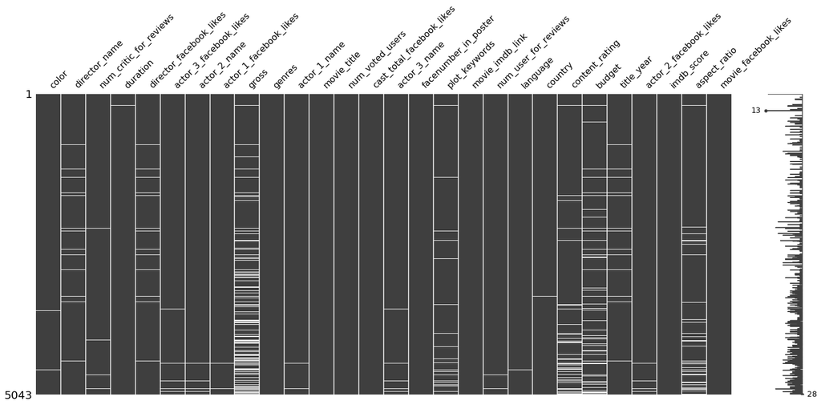

```python
mn.matrix(df)
```

As seen in the missingno matrix above, the dataset contains some missing values. The decision in whether to impute the missing values or to drop them from the dataset is simple when considering the vast number of missing entries in the gross column. Since the gross column is used to derive the target variable for this classification task, I do not want to impute any missing values, as this could lead to the misrepresentation of movie profitability in the dataset. Therefore, I will drop all the missing entries from the dataset, and choose to work with a smaller and pure subset of the original dataset.

```python
# Drop the missing entries and reset the index
df = df.dropna()
df.reset_index(drop = True, inplace=True)
```

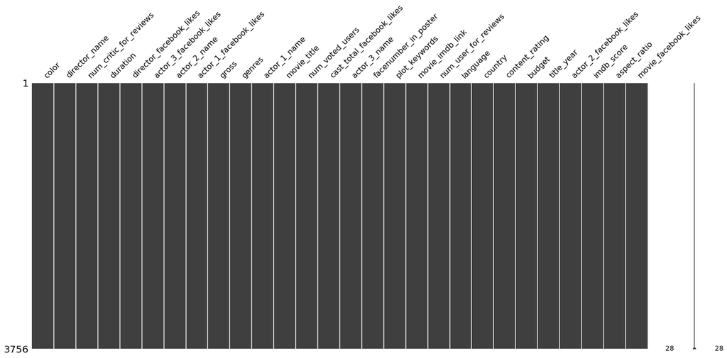

```python
# Check for completeness
mn.matrix(df)
```

Now, let's check if there are any duplicated rows (instances) in the dataset. To do this, I will use the duplicated and value_counts methods. Using these methods, if there is a duplicate instance in the dataset it will return True on the second occurrence of the duplicated row.

```python
df.duplicated().value_counts()
```

```
False    3723
True       33
dtype: int64
```

From the duplicated method above, it can be seen there are 33 duplicate instances in the dataset. Because this is such a small subset of the data, let's drop the duplicates using the drop_duplicates method in python as there is no benefit in keeping them in the dataset.

```python
df = df.drop_duplicates()
```

```python
df.duplicated().value_counts()
```

```
False    3723
dtype: int64
```

###### 2.1.3 Cleaning the Genres Feature

Viewing the dataset above, all the data aside from from the genres column is in working order. In solely looking at the genres column, it can be seen that the majority of instances in the dataset are assigned multiple genres, for example Action|Adventure|Sci-Fi| could all be a genre for one movie. Furthermore, there are 745 unique genres in the dataset, which would make extracting meaningful information regarding a specific genre fairly difficult. Say we wanted to test the hypothesis that comedies films were always more profitable than romance films. This would result in a tedious task as there are 278 instances in the data set that fall under both the comedy and romance genres. For simplicity, and to make this task less complex, I am going to extract the first genre of the film from the genres list, which I believe is the most relevant to the movie, and set this as the genre of the movie.

```python
len(df.genres.unique())
```

```
745
```

```python
df.genres.value_counts()
```

```
Comedy|Drama|Romance                                        147
Drama                                                       140
Comedy                                                      137
Comedy|Drama                                                137
Comedy|Romance                                              131
Drama|Romance                                               114
Crime|Drama|Thriller                                         81
Action|Crime|Thriller                                        55
Action|Crime|Drama|Thriller                                  50
Action|Adventure|Sci-Fi                                      46
Action|Adventure|Thriller                                    45
Comedy|Crime                                                 45
Horror                                                       43
Drama|Thriller                                               42
Crime|Drama|Mystery|Thriller                                 41
Crime|Drama                                                  40
Action|Adventure|Sci-Fi|Thriller                             34
Horror|Thriller                                              33
Horror|Mystery|Thriller                                      31
Drama|Mystery|Thriller                                       30
Biography|Drama                                              29
Action|Comedy|Crime                                          27
Adventure|Animation|Comedy|Family|Fantasy                    27
Action|Adventure|Fantasy                                     25
Horror|Mystery                                               25
Biography|Drama|Sport                                        23
Action|Thriller                                              22
Drama|Sport                                                  22
Action|Comedy|Crime|Thriller                                 21
Adventure|Animation|Comedy|Family                            21
                                                           ...
Adventure|Drama|History|Romance|War                           1
Comedy|Drama|Thriller                                         1
Action|Comedy|Mystery                                         1
Action|Adventure|Fantasy|Horror|Sci-Fi|Thriller               1
Fantasy|Horror|Mystery|Romance                                1
Action|Horror|Romance|Sci-Fi|Thriller                         1
Animation|Drama|Family|Musical|Romance                        1
Action|Adventure|Comedy|Fantasy|Mystery                       1
Fantasy|Horror|Mystery                                        1
Biography|Crime|Drama|History|Thriller                        1
Biography|Comedy|Crime|Drama|Romance                          1
Animation|Comedy|Crime|Drama|Family                           1
Action|Comedy|Crime|Sci-Fi|Thriller                           1
Adventure|Comedy|Family|Musical                               1
Adventure|Animation|Comedy                                    1
Biography|Crime|Drama|History|Music                           1
Adventure|Comedy|Fantasy|Sci-Fi                               1
Biography|Crime|Drama|Romance|Thriller                        1
Comedy|Family|Music                                           1
Action|Adventure|Animation|Drama|Mystery|Sci-Fi|Thriller      1
Action|Drama|Romance|Sci-Fi|Thriller                          1
Crime|Horror|Music|Thriller                                   1
Biography|Crime|Documentary|History|Thriller                  1
Comedy|Crime|Family|Mystery|Romance|Thriller                  1
Crime|Drama|History|Mystery|Thriller                          1
Adventure|Comedy|Drama|Fantasy|Romance                        1
Action|Animation|Comedy|Sci-Fi                                1
Action|Comedy|Crime|Drama                                     1
Action|Drama|Mystery|Thriller                                 1
Comedy|Horror|Mystery                                         1
Name: genres, Length: 745, dtype: int64
```

```python
# Grab the first genre in the list of genres for each movie
df.genres = df.genres.apply(lambda x: x.split('|')[0]).astype(str)
```

```python
df.genres.value_counts()
```

```
Comedy         984
Action         951
Drama          659
Adventure      366
Crime          253
Biography      204
Horror         159
Animation       45
Fantasy         37
Documentary     26
Mystery         23
Sci-Fi           7
Family           3
Western          2
Musical          2
Thriller         1
Romance          1
Name: genres, dtype: int64
```

###### 2.1.4 Eliminating Unecessary and Target Variables from the Dataset

To compress and reduce the dimentionality of the dataset, let's remove the features that are unnecessary for our prediction task and only keep the necessary features that will be used for this implementation of a wide and deep network.

```python
del df['facenumber_in_poster']
del df['plot_keywords']
del df['movie_imdb_link']
del df['movie_title']
```

```python
df.info()
```

```
<class 'pandas.core.frame.DataFrame'>
Int64Index: 3723 entries, 0 to 3755
Data columns (total 24 columns):
color                        3723 non-null object
director_name                3723 non-null object
num_critic_for_reviews       3723 non-null float64
duration                     3723 non-null float64
director_facebook_likes      3723 non-null float64
actor_3_facebook_likes       3723 non-null float64
actor_2_name                 3723 non-null object
actor_1_facebook_likes       3723 non-null float64
gross                        3723 non-null float64
genres                       3723 non-null object
actor_1_name                 3723 non-null object
num_voted_users              3723 non-null int64
cast_total_facebook_likes    3723 non-null int64
actor_3_name                 3723 non-null object
num_user_for_reviews         3723 non-null float64
language                     3723 non-null object
country                      3723 non-null object
content_rating               3723 non-null object
budget                       3723 non-null float64
title_year                   3723 non-null float64
actor_2_facebook_likes       3723 non-null float64
imdb_score                   3723 non-null float64
aspect_ratio                 3723 non-null float64
movie_facebook_likes         3723 non-null int64
dtypes: float64(12), int64(3), object(9)
memory usage: 727.1+ KB
```

###### 2.1.5 Preparing the Target Variable

Now, lets prepare the class variable (y) that this classification algorithm is trying to predict. The purpose of this wide and deep network is to predict if the gross return of a movie is greater than it's original budget based on it's features. Thus the target variable will be a boolean variable (encoded to 1 or 0) indicating if the movie grossed more than its original budget or not. Hence, this becomes a binary classification problem, with class 1 representing movies that grossed more than their original budget, and class 0 representing movies that grossed less than their original budget.

```python
# Calculate if a movie grossed more than its original budget or not and place the boolean in y
y = (df.gross > df.budget)
```

```python
y.head()
```

```
0     True
1     True
2    False
3     True
4    False
dtype: bool
```

```python
# Encode y
# 1: Movie grossed more than its orignal budget
# 0: Movie did not gross more than its original budget
y = y.apply(lambda x: 1 if x == 1 else 0)
```

```python
y.head()
```

```
0    1
1    1
2    0
3    1
4    0
dtype: int64
```

```python
# View the class distribution
y.value_counts()
```

```
1    1999
0    1724
dtype: int64
```

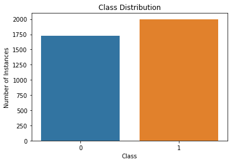

```python
# Visualize the class distribution
sns.countplot(y)
plt.title('Class Distribution')
plt.ylabel('Number of Instances')
plt.xlabel('Class')
plt.show()
```

```python
df.insert(0, column = 'class', value = y)
```

```python
df.head()
```

|  | class | color | director_name | num_critic_for_reviews | duration | director_facebook_likes | actor_3_facebook_likes | actor_2_name | actor_1_facebook_likes | gross | ... | num_user_for_reviews | language | country | content_rating | budget | title_year | actor_2_facebook_likes | imdb_score | aspect_ratio | movie_facebook_likes |
| --- | --- | --- | --- | --- | --- | --- | --- | --- | --- | --- | --- | --- | --- | --- | --- | --- | --- | --- | --- | --- | --- |
| 0 | 1 | Color | James Cameron | 723.0 | 178.0 | 0.0 | 855.0 | Joel David Moore | 1000.0 | 760505847.0 | ... | 3054.0 | English | USA | PG-13 | 237000000.0 | 2009.0 | 936.0 | 7.9 | 1.78 | 33000 |
| 1 | 1 | Color | Gore Verbinski | 302.0 | 169.0 | 563.0 | 1000.0 | Orlando Bloom | 40000.0 | 309404152.0 | ... | 1238.0 | English | USA | PG-13 | 300000000.0 | 2007.0 | 5000.0 | 7.1 | 2.35 | 0 |
| 2 | 0 | Color | Sam Mendes | 602.0 | 148.0 | 0.0 | 161.0 | Rory Kinnear | 11000.0 | 200074175.0 | ... | 994.0 | English | UK | PG-13 | 245000000.0 | 2015.0 | 393.0 | 6.8 | 2.35 | 85000 |
| 3 | 1 | Color | Christopher Nolan | 813.0 | 164.0 | 22000.0 | 23000.0 | Christian Bale | 27000.0 | 448130642.0 | ... | 2701.0 | English | USA | PG-13 | 250000000.0 | 2012.0 | 23000.0 | 8.5 | 2.35 | 164000 |
| 4 | 0 | Color | Andrew Stanton | 462.0 | 132.0 | 475.0 | 530.0 | Samantha Morton | 640.0 | 73058679.0 | ... | 738.0 | English | USA | PG-13 | 263700000.0 | 2012.0 | 632.0 | 6.6 | 2.35 | 24000 |

5 rows × 25 columns

###### 2.1.6 Narrowing the Focus of the Dataset

The original movie dataset consisted of movie data collected on 5,043 national and international films. Because of this, the dataset contained a vast number of unique instances in many of the feature columns. For instance, the names of the three lead roles in the movie, each had over 1,400 unique instances. This was also the case with the director_name, country, and content_rating columns. While these columns did not have nearly as many unique instances, they were still a nuisance for the classification task.

As a result of the vast number of unique instances in the dataset, when using the keras implementation of a wide and deep network, often the predict method would fail, because the test set would contain an instance that the training set did not.

To solve this problem, and also enhance the target user third party user of this model, I chose to narrow the focus of the dataset towards the following features:

- Country: U.S. and U.K.
- Language: English
- Genres: Comedy, Action, Drama, Adventure, Crime, Biography, and Horror
- Content Rating: R, PG-13, PG, and G

By narrowing the focus of this dataset, the primary target users becomes U.S. based movie companies like Disney, Warner Bros. and Fox. The focus of this dataset is now aimed towards U.S. based movies, where the industry is largest and the algorithm is most applicable.

```python
df.country.value_counts()
```

```
USA               2961
UK                 313
France             101
Germany             79
Canada              59
Australia           39
Spain               21
Japan               15
Hong Kong           13
China               12
New Zealand         11
Italy               11
South Korea          8
Denmark              8
Ireland              7
Mexico               6
Brazil               5
India                5
Thailand             4
Iran                 4
Norway               4
Czech Republic       3
Netherlands          3
South Africa         3
Argentina            3
Russia               3
Hungary              2
Romania              2
Taiwan               2
Georgia              1
Chile                1
Israel               1
Colombia             1
Peru                 1
Iceland              1
Indonesia            1
New Line             1
Official site        1
Aruba                1
Belgium              1
Greece               1
Afghanistan          1
Finland              1
West Germany         1
Poland               1
Name: country, dtype: int64
```

```python
df = df[df.country != 'Indonesia']
df = df[df.country != 'Belgium']
df = df[df.country != 'Afghanistan']
df = df[df.country != 'Iceland']
df = df[df.country != 'Official site']
df = df[df.country != 'Poland']
df = df[df.country != 'Greece']
df = df[df.country != 'West Germany']
df = df[df.country != 'Finland']
df = df[df.country != 'New Line']
df = df[df.country != 'Peru']
df = df[df.country != 'Aruba']
df = df[df.country != 'Chile']
df = df[df.country != 'Colombia']
df = df[df.country != 'Israel']
df = df[df.country != 'Georgia']
df = df[df.country != 'Romania']
df = df[df.country != 'Hungary']
df = df[df.country != 'Taiwan']
df = df[df.country != 'Russia']
df = df[df.country != 'Czech Republic']
df = df[df.country != 'Argentina']
df = df[df.country != 'Netherlands']
df = df[df.country != 'South Africa']
df = df[df.country != 'Thailand']
df = df[df.country != 'Norway']
df = df[df.country != 'Iran']
df = df[df.country != 'India']
df = df[df.country != 'Brazil']
df = df[df.country != 'Mexico']
df = df[df.country != 'Denmark']
df = df[df.country != 'South Korea']
df = df[df.country != 'Italy']
df = df[df.country != 'New Zealand']
df = df[df.country != 'China']
df = df[df.country != 'Hong Kong']
df = df[df.country != 'Japan']
df = df[df.country != 'Spain']
df = df[df.country != 'Australia']
df = df[df.country != 'Canada']
df = df[df.country != 'Germany']
df = df[df.country != 'France']
df = df[df.country != 'Ireland']
```

```python
df.country.value_counts()
```

```
USA    2961
UK      313
Name: country, dtype: int64
```

```python
# Only English movies
df = df[df.language == 'English']
```

```python
df.language.value_counts()
```

```
English    3256
Name: language, dtype: int64
```

```python
# Only Comedy, Action, Drama, Adventure, Crime, Biography, and Horror movies
df = df[df.genres != 'Thriller']
df = df[df.genres != 'Musical']
df = df[df.genres != 'Western']
df = df[df.genres != 'Family']
df = df[df.genres != 'Sci-Fi']
df = df[df.genres != 'Mystery']
df = df[df.genres != 'Romance']
df = df[df.genres != 'Documentary']
df = df[df.genres != 'Fantasy']
df = df[df.genres != 'Animation']
```

```python
df.genres.value_counts()
```

```
Comedy       903
Action       817
Drama        549
Adventure    326
Crime        220
Biography    178
Horror       140
Name: genres, dtype: int64
```

```python
# Only R, PG-13, PG, and G movies
df = df[df.content_rating != 'M']
df = df[df.content_rating != 'Passed']
df = df[df.content_rating != 'NC-17']
df = df[df.content_rating != 'Approved']
df = df[df.content_rating != 'Not Rated']
df = df[df.content_rating != 'X']
df = df[df.content_rating != 'Unrated']
```

```python
df.content_rating.value_counts()
```

```
R        1386
PG-13    1141
PG        484
G          65
GP          1
Name: content_rating, dtype: int64
```

```python
# Delete the director name and the three lead role actors feature columns
del df['director_name']
del df['actor_1_name']
del df['actor_2_name']
del df['actor_3_name']
```

```python
df.info()
```

```
<class 'pandas.core.frame.DataFrame'>
Int64Index: 3077 entries, 0 to 3753
Data columns (total 21 columns):
class                        3077 non-null int64
color                        3077 non-null object
num_critic_for_reviews       3077 non-null float64
duration                     3077 non-null float64
director_facebook_likes      3077 non-null float64
actor_3_facebook_likes       3077 non-null float64
actor_1_facebook_likes       3077 non-null float64
gross                        3077 non-null float64
genres                       3077 non-null object
num_voted_users              3077 non-null int64
cast_total_facebook_likes    3077 non-null int64
num_user_for_reviews         3077 non-null float64
language                     3077 non-null object
country                      3077 non-null object
content_rating               3077 non-null object
budget                       3077 non-null float64
title_year                   3077 non-null float64
actor_2_facebook_likes       3077 non-null float64
imdb_score                   3077 non-null float64
aspect_ratio                 3077 non-null float64
movie_facebook_likes         3077 non-null int64
dtypes: float64(12), int64(4), object(5)
memory usage: 528.9+ KB
```

###### 2.1.7 Description of the Final Dataset

The final dataset used for the implementation of this wide and deep network consists of 21 categorical and numeric features collected of 3,077 US movies. The dataset contains 5 categorical features and 16 continuous features. A description of each feature and its corresponding variable type is detailed below.

- color: Movie color. Black and white or color. Categorical.
- num_critic_for_reviews: Number of critics that reviewed the movie. Continuous.
- duration: Time duration of the movie. Continuous.
- director_facebook_likes: Number of facebook likes the director has. Continuous.
- actor_3_facebook_likes: Number of facebook likes the 3rd lead role actor has. Standard Scaled. Continuous.
- actor_1_facebook_likes: Number of facebook likes the 1st star role actor has. Continuous.
- genres: Genre of the movie. Genres include Comedy, Action, Drama, Adventure, Crime, Biography, Horror. Categorical.
- num_voted_users: Number of users who voted positively on the movie. Continuous.
- cast_total_facebook_likes: Number of facebook likes the cast as a whole has. Continuous.
- num_user_for_reviews: Number if users who reviewed the movie. Continuous.
- language: Language of the movie. English. Categorical.
- country: Country the movie was made in. US. or U.K. Categorical.
- content_rating: Movie Rating. Ratings include PG-13, PG, G, R, and GP. Categorical.
- budget: Movies Budget. Continuous.
- title_year: Year the movie came out. Continuous.
- actor_2_facebook_likes: Number of facebook likes the 2nd lead role actor has. Continuous.
- imdb_score: Moive IMDB score. Continuous.
- aspect_ratio: Movie aspect ratio. Continuous.
- movie_facebook_likes: Number of facebook likes the moive has. Continuous.
- class: Target variable. 1 if the movie grossed more than its budget, 0 if the movie did not gross more than its budget.

### 2.2 Cross-Product Feature Selection

In choosing columns to transform into cross-product features, we must consider the correlation amongst the features. Ideal feature candidates to transform into cross-product features are features that are likely correlated in light of our classification task, thus make sense to be compressed into a single feature and memorized by the wide branch of the network. That is, what features should be memorized by the wide branch of the network to better predict the profitability of a movie. For the cross-product feature selection I have chose to create 2 cross-product features.

The first features I selected to cross are the GENRE and CONTENT_RATING of the movie. I believe these features makes sense to cross, as the combination of the two possibly correlates to the profitability of a movie. For example a PG rated comedy might appeal to a greater portion of the population than an R rated horror movie, and therefore have a higher profitability because more people are likely to buy tickets and see the movie.

The second features I selected to cross are the LANGUAGE of the movie and COUNTRY it was made it. I believe these are likely correlated to the profitability of a movie, because for example a movie in English made in America, where the movie industry is large, is probably going to generate a greater profit than a movie in English made in the U.K., where the film industry is likely smaller than in the U.S.

### 2.3 Performance Evaluation Metric

In choosing an appropriate evaluation metric to evaluate this algorithms performance, it is important to first understand the algorithm's classification task. The classification task for this algorithm, as stated in the business case, is to predict whether a movie will gross more or less than its original budget. Also, in the business case it is stated that, the algorithm needs to achieve greater accuracy than the current industry standard which is roughly 51%.

In really looking into the classification task of this algorithm, the focal point is to predict if a moive is going to be profitable before the film is made. Thus, studios, producers, and investors, could use this algorithm to decide whether or not to invest in making a movie, before the fact. Let's consider a simple example to bring to light the evaluation metric that most suits this algorithm. Say Warner Bros. is going to make the next Batman, and they want to decide if they should make a fourth Batman or lay it to rest. Since the are a giant corporate Hollywood studio, obviously the question they will ask is, will the movie make money. Using our algorithm, they put in the moives budget, rating, genre, ect..., and the algorithm predicts the movie will gross more than its original budget, and therefore be profitable. Great! Warner Bros makes the movie, sinks millions of dollars into the film, and no one wants to see a fourth Batman, the movie tanks, and Warner Bros loses all the money they invested into making the film. This example illustrates the case of our algorithm predicting a false positive, or predicting the movie would be profitable when in fact it will not be, and this the algorithm's greatest pitfall.

Thus, the most appropriate performance evaluation metric for this algorithm is precision. We want our algorithm to be a precise as possible at identifying movies that will gross more than their original budget. An algorithm with higher precision in turn will predict a lower number of false positives, which is what we want to minimize here. However, optimizing precision comes at the price of lower recall. An algorithm that has higher recall attempts to reduce the number of false negatives predicted by the algorithm. For the use case of this algorithm, predicting false negatives is better than predicting false positives, which becomes apparent in considering the following example.

Again, Warner Bros. wants to make another movie, we'll say Harry Potter this time. They again use our algorithm, and our algorithm predicts the movie will not gross more than its original budget, and therefore will not be profitable. Thus, Warner Bros. decides not to make the movie. It turns out Disney, who does not use our algorithm, makes the movie instead and makes a profit, i.e. our algorithm predicted a false negative. While Warner Bros. missed out on a potential profitable opportunity, they did not lose any money by following our algorithms advice.

In really simple terms precision is wanting to be extra certain about a prediction, and recall is not wanting to miss out, and for this case being certain is paramount.

Therefore, PRECISION is the appropriate metric in which to evaluate this algorithm's performance, which is defined mathematically as the number of true positives divided by the number of true positives plus the number of false positives predicted by the algorithm, or:

$$ Precision = \frac{True\hspace{1mm} Positives} {True\hspace{1mm} Positives\hspace{1mm} + \hspace{1mm}False\hspace{1mm}Positives}$$

Also, essential in choosing an appropriate evaluation criteria is the class distribution of the dataset. Observing the class distribution of the dataset will also shed light on how to evaluate the performance of an algorithm. Algorithms that evaluate datasets containing a large class imbalance often need to be evaluated differently than algorithms that evaluate datasets with uniform class distribution.

```python
y.value_counts()
```

```
1    1999
0    1724
dtype: int64
```

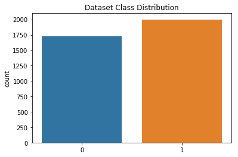

```python
sns.countplot(y)
plt.title('Dataset Class Distribution')
plt.show()
```

As can be seen from the distribution of classes in the dataset, the class balance is fairly equal. To be exact there are 1,724 instances in class 0 and 1,999 instances in class 1. Due to the fact the class distribution is equal, and that this algorithm performs binary classification, we do not need account for class imbalance when evaluating the algorithms performance.

### 2.4 Method for Dividing Data into Train and Test Splits

In choosing an appropriate method for dividing the dataset into training and testing splits, two characteristics of the dataset should be taken into account. The first being the size of the dataset, meaning the number of instances we have data on, and the second being how the data would likely be obtained and used in the algorithm in practice.

In addressing the size of the dataset, after preparing the data, I am left with 3,077 instances in the dataset. Due to the small amount of instances in the dataset, K-Fold cross validation would be the appropriate method to use to divide the data into training and testing splits. K-Fold cross validation efficiently uses small amounts of data to train and test an algorithm by diving the data into K number of folds, training the algorithm on K-1 folds, and testing the algorithm on the remaining fold. Therefore, even though the dataset has a limited number of instances, our algorithm will still be trained and tested over vast amounts of data. Thus, K-Fold cross validation will efficiently use the small amount of data in this dataset to adequately train and test the algorithm.

Next addressing how this algorithm would be used in practice. In practice, a movie studio, producer, or investor, would likely place the feature data regarding the movie they are considering making into this algorithm to predict whether or not the movie would be profitable. Thus single instances will likely be placed into the algorithm and predicted upon. Because of this I believe stratification is essential in cross validation technique to accurately represent the class distribution of the dataset as a whole when training and testing the algorithm.

As a result of the above the most appropriate method for dividing the dataset into training and testing splits is Stratified K-Fold cross validation.

# 3. Modeling

#### 3.1 Encoding and Standard Scaling the Dataset

Before being passed into the wide and deep network, the dataset needs to undergo two more processing steps. The first is to encode the categorical features of the dataset, and the second is two standard scale the continuous features in the dataset. For this assignment, I chose to label encode the categorical data and standard scale the numeric data. While label encoding the categorical data introduces an ordinal aspect into categorical data, because I got rid of the vast number of unique instances in the dataset, I do not believe introducing ordinality into the categorical features of this data will corrupt the prediction task.

```python
categorical_feature_columns = ['color', 'genres', 'language', 'country', 'content_rating']
numeric_feature_columns = ['num_critic_for_reviews', 'duration', 'director_facebook_likes', 'actor_3_facebook_likes', 'actor_1_facebook_likes', 'num_voted_users', 'cast_total_facebook_likes', 'num_user_for_reviews', 'budget', 'title_year', 'actor_2_facebook_likes', 'imdb_score', 'aspect_ratio', 'movie_facebook_likes']
categorical_feature_columns_ints = [x + '_int' for x in categorical_feature_columns]
feature_columns = categorical_feature_columns_ints + numeric_feature_columns

encoders = dict()

for col in categorical_feature_columns:
    df[col] = df[col].str.strip()
    encoders[col] = LabelEncoder()
    df[col + '_int'] = encoders[col].fit_transform(df[col])

for col in numeric_feature_columns:
    df[col] = df[col].astype(np.float)
    ss = StandardScaler()
    df[col] = ss.fit_transform(df[col].values.reshape(-1,1))
```

```python
df.reset_index(drop = True, inplace = True)
```

```python
df.head()
```

|  | class | color | num_critic_for_reviews | duration | director_facebook_likes | actor_3_facebook_likes | actor_1_facebook_likes | gross | genres | num_voted_users | ... | title_year | actor_2_facebook_likes | imdb_score | aspect_ratio | movie_facebook_likes | color_int | genres_int | language_int | country_int | content_rating_int |
| --- | --- | --- | --- | --- | --- | --- | --- | --- | --- | --- | --- | --- | --- | --- | --- | --- | --- | --- | --- | --- | --- |
| 0 | 1 | Color | 4.409150 | 3.105551 | -0.268806 | 0.010179 | -0.445080 | 760505847.0 | Action | 4.919377 | ... | 0.648554 | -0.263818 | 1.423183 | -1.242981 | 1.049747 | 1 | 0 | 0 | 1 | 3 |
| 1 | 1 | Color | 1.059556 | 2.692112 | -0.094468 | 0.083229 | 1.905379 | 309404152.0 | Action | 2.285717 | ... | 0.420563 | 0.581603 | 0.655217 | 0.904896 | -0.437467 | 1 | 0 | 0 | 1 | 3 |
| 2 | 0 | Color | 3.446440 | 1.727420 | -0.268806 | -0.339455 | 0.157602 | 200074175.0 | Action | 1.045932 | ... | 1.332525 | -0.376777 | 0.367230 | 0.904896 | 3.393236 | 1 | 0 | 0 | 0 | 3 |
| 3 | 1 | Color | 5.125215 | 2.462423 | 6.543697 | 11.166717 | 1.121893 | 448130642.0 | Action | 6.557597 | ... | 0.990540 | 4.326089 | 1.999158 | 0.904896 | 6.953535 | 1 | 0 | 0 | 1 | 3 |
| 4 | 0 | Color | 2.332561 | 0.992416 | -0.121718 | -0.153555 | -0.466777 | 73058679.0 | Action | 0.641894 | ... | 0.990540 | -0.327059 | 0.175238 | 0.904896 | 0.644143 | 1 | 0 | 0 | 1 | 3 |

5 rows × 26 columns

```python
# Create X and y for use in all modeling
X = df[feature_columns].values
y = df['class'].values
```

#### 3.2 Several Wide and Deep Network Architectures

The code below in the create model function contains the architecture for the wide and deep network used for Model 1, Model 2, and Model 3 below which fill the requirement to "create several combined wide and deep networks to classify your data using Keras."

In the models below, you may notice I vary the columns that I cross and a few other model parameters. While I argued that genre and content_rating and language and country are the most appropriate features to cross, for the sake of "creating several models" I though it would be interesting to experiment with various cross product features.

It should be noted when visualizing the performance of the models on the training data and validation data using the keras history return parameter, I am limited to the accuracy metric provided by keras. While this accuracy does not reflect the evaluation metric I chose, precision, for the sake of the visualization it serves it purpose. Notice that in the model statistics the precision of the model is the metric the model is evaluated on.

```python
def create_model(X_train, X_test, X_train_numeric, categorical_feature_columns_ints, cross_columns):

    embed_branches = []
    X_ints_train = []
    X_ints_test = []
    all_inputs = []
    all_branch_outputs = []

    for cols in cross_columns:
        enc = LabelEncoder()
        X_crossed_train = X_train[cols].apply(lambda x: '_'.join(x), axis = 1)
        X_crossed_test = X_test[cols].apply(lambda x: '_'.join(x), axis = 1)

        enc.fit(np.hstack((X_crossed_train.values, X_crossed_test.values)))
        X_crossed_train = enc.transform(X_crossed_train)
        X_crossed_test = enc.transform(X_crossed_test)
        X_ints_train.append(X_crossed_train)
        X_ints_test.append(X_crossed_test)

        N = max(X_ints_train[-1] + 1)

        inputs = Input(shape=(1,),dtype='int32', name = '_'.join(cols))
        all_inputs.append(inputs)
        x = Embedding(input_dim = N, output_dim = int(np.sqrt(N)), input_length = 1, name = '_'.join(cols) + '_embed')(inputs)
        x = Flatten()(x)
        all_branch_outputs.append(x)

    wide_branch = concatenate(all_branch_outputs, name='wide_concat')

    all_branch_outputs = []

    for col in categorical_feature_columns_ints:
        X_ints_train.append( X_train[col].values )
        X_ints_test.append( X_test[col].values )

        N = max(X_ints_train[-1]+1)

        inputs = Input(shape = (1,), dtype = 'int32', name = col)
        all_inputs.append(inputs)
        x = Embedding(input_dim = N, output_dim = int(np.sqrt(N)), input_length = 1, name = col + '_embed')(inputs)
        x = Flatten()(x)
        all_branch_outputs.append(x)

    all_inputs.append(Input(shape=(X_train_numeric.shape[1],), sparse = False, name = 'numeric_data'))

    x = Dense(units = 20, activation = 'relu',name = 'numeric_1')(all_inputs[-1])
    all_branch_outputs.append(x)

    # merge the branches together
    deep_branch = concatenate(all_branch_outputs,name='concat_embeds')
    deep_branch = Dense(units = 50,activation = 'relu', name = 'deep1')(deep_branch)
    deep_branch = Dense(units = 25,activation = 'relu', name = 'deep2')(deep_branch)
    deep_branch = Dense(units = 10,activation = 'relu', name = 'deep3')(deep_branch)

    final_branch = concatenate([wide_branch, deep_branch], name = 'concat_deep_wide')
    final_branch = Dense(units = 1,activation = 'sigmoid',name = 'combined')(final_branch)

    model = Model(inputs = all_inputs, outputs = final_branch)

    return model, X_ints_train, X_ints_test

# Code Reference: Eric Larson: http://localhost:8888/notebooks/Machine%20Learning%20In%20Python/EricLarson/10.%20Keras%20Wide%20and%20Deep.ipynb
```

###### 3.2.1 Model 1

Model 1 of the wide and deep network has the following characterisitcs:

- cross_columns: [genres and color] and [language and country]
- Number of Deep Layers: 3
- Activation of Deep Layers: relu
- Activation of final Layer: sigmoid
- Optimizer: Standard Gradient Descent
- loss: Binary Cross Entropy
- epochs: 10
- batch_size = 50

```python
K = 10

cross_columns_1 = [['genres', 'color'], ['language', 'country']]

precision_score_list_m1 = []

skf = StratifiedKFold(n_splits = K, shuffle = True).split(X,y)

for i, (train, test) in enumerate(skf):
    print('Fold:', i)

    X_train = df.iloc[train]
    X_test = df.iloc[test]
    y_train = df['class'].iloc[train].values.astype(np.int)
    y_test = df['class'].iloc[test].values.astype(np.int)

    X_train_numeric = X_train[numeric_feature_columns].values
    X_test_numeric = X_test[numeric_feature_columns].values

    model, X_ints_train, X_ints_test = create_model(X_train, X_test, X_train_numeric, categorical_feature_columns_ints, cross_columns_1)

    model.compile(optimizer = 'sgd', loss = 'binary_crossentropy', metrics = ['accuracy'])
    history_1 = model.fit(X_ints_train + [X_train_numeric], y_train, epochs = 10, batch_size = 50, verbose = 0, validation_data = (X_ints_test + [X_test_numeric], y_test))

    yhat = np.round(model.predict(X_ints_test + [X_test_numeric]))

    score = precision_score(y_test, yhat)
    precision_score_list_m1.append(score)

    print(confusion_matrix(y_test, yhat))
    print('Precision Score:', score)
print('Model 1 Max Precision Score:', max(precision_score_list_m1))
print('Model 1 Mean Precision Score:' , np.mean(precision_score_list_m1))
print('Model 1 Standard Deviation of Precision Score:', np.std(precision_score_list_m1) )
```

```
Fold: 0
[[  0 136]
 [  0 173]]
Precision Score: 0.5598705501618123
Fold: 1
[[ 44  91]
 [ 30 143]]
Precision Score: 0.6111111111111112
Fold: 2
[[ 51  84]
 [ 32 141]]
Precision Score: 0.6266666666666667
Fold: 3
[[  6 129]
 [  2 171]]
Precision Score: 0.57
Fold: 4
[[ 10 125]
 [  5 168]]
Precision Score: 0.5733788395904437
Fold: 5
[[ 64  71]
 [ 30 143]]
Precision Score: 0.6682242990654206
Fold: 6
[[ 47  88]
 [ 34 138]]
Precision Score: 0.6106194690265486
Fold: 7
[[ 23 112]
 [ 15 157]]
Precision Score: 0.5836431226765799
Fold: 8
[[ 70  65]
 [ 40 132]]
Precision Score: 0.6700507614213198
Fold: 9
[[ 61  74]
 [ 45 127]]
Precision Score: 0.6318407960199005
Model 1 Max Precision Score: 0.6700507614213198
Model 1 Mean Precision Score: 0.6105405615739803
Model 1 Standard Deviation of Precision Score: 0.03728057597756181
```

From the statistics above, it is seen that model 1 achieved a mean precision score of 61 % with standard deviation of 0.037.

```python
# Visual depiction of the wide and deep network in model 1
SVG(model_to_dot(model).create(prog = 'dot', format = 'svg'))
```

[figure not shown]

Below is the visualization of the performance of the network in model 1 on the training data and validation data, versus the number of training iterations.

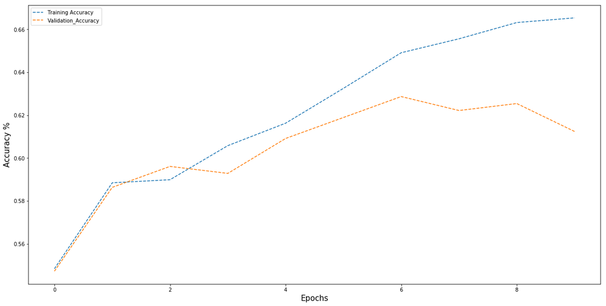

```python
%matplotlib inline

plt.figure(figsize = (20,10))
plt.plot(history_1.history['acc'], label = 'Training Accuracy', linestyle = '--')
plt.plot(history_1.history['val_acc'], label = 'Validation_Accuracy', linestyle = '--')
plt.ylabel('Accuracy %', size = 15)
plt.xlabel('Epochs', size = 15)
plt.legend()
plt.show()
```

In visualizing the the performance of the network in model 1 on the training and validation data, it can be seen that the training accuracy increases continuously with the number of training iterations, while the validation accuracy reaches a global maximum around 6 epochs and then falls off. This could be due to the model slightly over-fitting the training data, however with such a low number of epochs this is not usually the case. Lets continue to investigate this in the next model.

###### 3.2.2 Model 2

Model 2 of the wide and deep network has the following characterisitcs:

- cross_columns: [language and content_rating] and [genre and country]
- Number of Deep Layers: 3
- Activation of Deep Layers: relu
- Activation of final Layer: sigmoid
- Optimizer: Ada Grad
- loss: mean_squared_error
- epochs: 10
- batch_size = 10

```python
K = 10

cross_columns = [['language', 'content_rating'], ['genres', 'country']]

precision_score_list_m2 = []

skf = StratifiedKFold(n_splits = K, shuffle = True).split(X,y)

for i, (train, test) in enumerate(skf):
    print('Fold:', i)

    X_train = df.iloc[train]
    X_test = df.iloc[test]
    y_train = df['class'].iloc[train].values.astype(np.int)
    y_test = df['class'].iloc[test].values.astype(np.int)

    X_train_numeric = X_train[numeric_feature_columns].values
    X_test_numeric = X_test[numeric_feature_columns].values

    model, X_ints_train, X_ints_test = create_model(X_train, X_test, X_train_numeric, categorical_feature_columns_ints, cross_columns)

    model.compile(optimizer = 'adagrad', loss = 'mean_squared_error', metrics = ['accuracy'])

    history_2 = model.fit(X_ints_train + [X_train_numeric], y_train, epochs = 10, batch_size = 10, verbose = 0, validation_data = (X_ints_test + [X_test_numeric], y_test))

    yhat = np.round(model.predict(X_ints_test + [X_test_numeric]))

    score = precision_score(y_test, yhat)
    precision_score_list_m2.append(score)

    print(confusion_matrix(y_test, yhat))
    print('Precision Score:', score)

print('Model 2 Max Precision Score:', max(precision_score_list_m2))
print('Model 2 Mean Precision Score:' , np.mean(precision_score_list_m2))
print('Model 2 Standard Deviation of Precision Score:', np.std(precision_score_list_m2) )
```

```
Fold: 0
[[101  35]
 [ 51 122]]
Precision Score: 0.7770700636942676
Fold: 1
[[ 87  48]
 [ 38 135]]
Precision Score: 0.7377049180327869
Fold: 2
[[ 93  42]
 [ 42 131]]
Precision Score: 0.7572254335260116
Fold: 3
[[ 89  46]
 [ 47 126]]
Precision Score: 0.7325581395348837
Fold: 4
[[ 94  41]
 [ 39 134]]
Precision Score: 0.7657142857142857
Fold: 5
[[ 92  43]
 [ 31 142]]
Precision Score: 0.7675675675675676
Fold: 6
[[ 90  45]
 [ 40 132]]
Precision Score: 0.7457627118644068
Fold: 7
[[ 96  39]
 [ 30 142]]
Precision Score: 0.7845303867403315
Fold: 8
[[ 90  45]
 [ 42 130]]
Precision Score: 0.7428571428571429
Fold: 9
[[ 96  39]
 [ 35 137]]
Precision Score: 0.7784090909090909
Model 2 Max Precision Score: 0.7845303867403315
Model 2 Mean Precision Score: 0.7589399740440775
Model 2 Standard Deviation of Precision Score: 0.017507451828876208
```

From the statistics above it is seen that model 2 achieved a mean precision score of 75.8 % with standard deviation of 0.017. If I were to do a back of the envelope comparison between model 1 and 2, I would say model 2 is the better model due to the higher average precision score and the lower standard deviation in the precision scores. However, because so many parameters were changed from model 1 to model 2 it is hard to attribute this boost in performance to one parameter in particular.

```python
# Visual depiction of the wide and deep network in model 2
SVG(model_to_dot(model).create(prog = 'dot', format = 'svg'))
```

[figure not shown]

Below is the visualization of the performance of the network in model 2 on the training data and validation data, versus the number of training iterations.

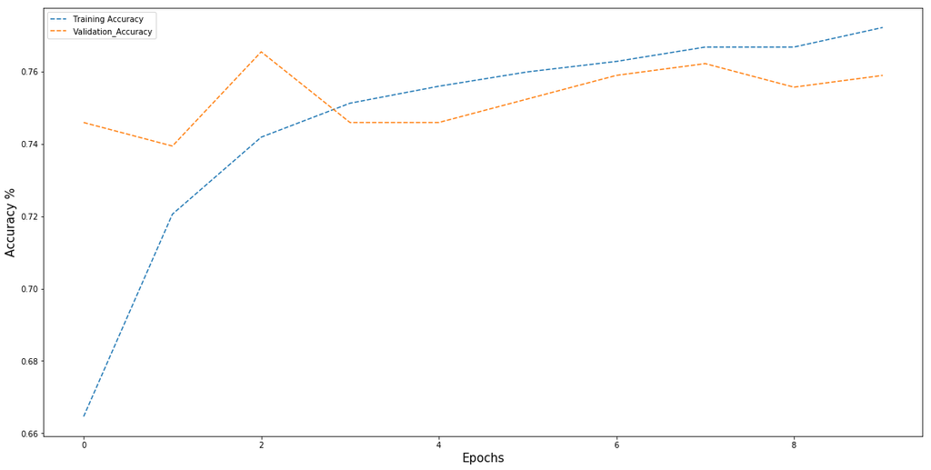

```python
%matplotlib inline

plt.figure(figsize = (20,10))
plt.plot(history_2.history['acc'], label = 'Training Accuracy', linestyle = '--')
plt.plot(history_2.history['val_acc'], label = 'Validation_Accuracy', linestyle = '--')
plt.ylabel('Accuracy %', size = 15)
plt.xlabel('Epochs', size = 15)
plt.legend()
plt.show()
```

###### 3.2.3 Model 3

Model 3 of the wide and deep network has the following characterisitcs:

- cross_columns: [content_rating and genre] and [language and country]
- Number of Deep Layers: 3
- Activation of Deep Layers: relu
- Activation of final Layer: sigmoid
- Optimizer: adagrad
- loss: Binary Cross Entropy
- epochs: 100
- batch_size = 10

```python
K = 10

cross_columns = [['content_rating', 'genres'], ['language', 'country']]

precision_score_list_m3 = []

skf = StratifiedKFold(n_splits = K, shuffle = True).split(X,y)

for i, (train, test) in enumerate(skf):
    print('Fold:', i)

    X_train = df.iloc[train]
    X_test = df.iloc[test]
    y_train = df['class'].iloc[train].values.astype(np.int)
    y_test = df['class'].iloc[test].values.astype(np.int)

    X_train_numeric = X_train[numeric_feature_columns].values
    X_test_numeric = X_test[numeric_feature_columns].values

    model, X_ints_train, X_ints_test = create_model(X_train, X_test, X_train_numeric, categorical_feature_columns_ints, cross_columns)

    model.compile(optimizer = 'adagrad', loss = 'binary_crossentropy', metrics = ['accuracy'])

    history_3 = model.fit(X_ints_train + [X_train_numeric], y_train, epochs = 100, batch_size = 10, verbose = 0, validation_data = (X_ints_test + [X_test_numeric], y_test))

    yhat = np.round(model.predict(X_ints_test + [X_test_numeric]))

    score = precision_score(y_test, yhat)
    precision_score_list_m3.append(score)

    print(confusion_matrix(y_test, yhat))
    print('Precision Score:', score)

print('Model 3 Max Precision Score:', max(precision_score_list_m3))
print('Model 3 Mean Precision Score:' , np.mean(precision_score_list_m3))
print('Model 3 Standard Deviation of Precision Score:', np.std(precision_score_list_m3) )
```

```
Fold: 0
[[100  36]
 [ 30 143]]
Precision Score: 0.7988826815642458
Fold: 1
[[ 82  53]
 [ 35 138]]
Precision Score: 0.7225130890052356
Fold: 2
[[ 95  40]
 [ 35 138]]
Precision Score: 0.7752808988764045
Fold: 3
[[ 93  42]
 [ 30 143]]
Precision Score: 0.772972972972973
Fold: 4
[[ 89  46]
 [ 34 139]]
Precision Score: 0.7513513513513513
Fold: 5
[[ 97  38]
 [ 29 144]]
Precision Score: 0.7912087912087912
Fold: 6
[[ 92  43]
 [ 34 138]]
Precision Score: 0.7624309392265194
Fold: 7
[[ 89  46]
 [ 40 132]]
Precision Score: 0.7415730337078652
Fold: 8
[[ 93  42]
 [ 37 135]]
Precision Score: 0.7627118644067796
Fold: 9
[[ 87  48]
 [ 30 142]]
Precision Score: 0.7473684210526316
Model 3 Max Precision Score: 0.7988826815642458
Model 3 Mean Precision Score: 0.7626294043372797
Model 3 Standard Deviation of Precision Score: 0.021933898348847652
```

From the model 3 statistics above, it is seen that model 3 achieved a mean precision score of 76.2 % with standard deviation of 0.022. While model 3 has achieved the greatest mean precision score, its standard deviation also slightly increased from model 2.

```python
# Visual depiction of the wide and deep network in model 3
SVG(model_to_dot(model).create(prog = 'dot', format = 'svg'))
```

[figure not shown]

Below is the visualization of the performance of the network in model 3 on the training data and validation data, versus the number of training iterations.

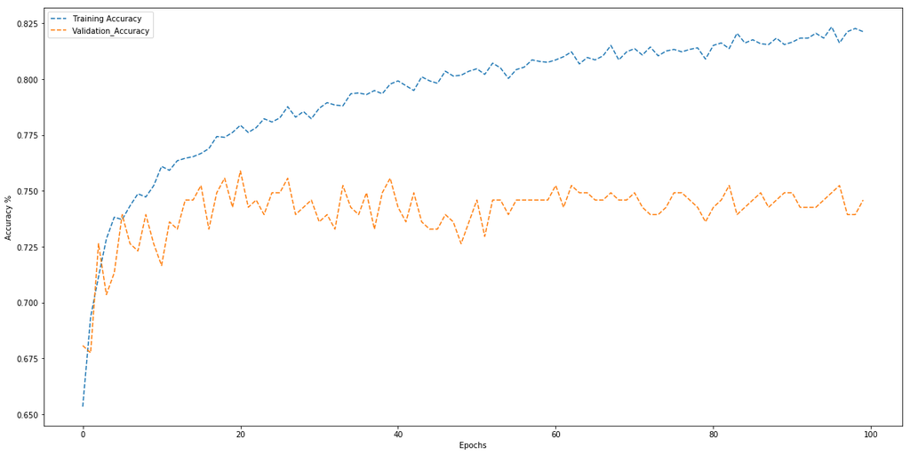

```python
%matplotlib inline

plt.figure(figsize = (20,10))
plt.plot(history_3.history['acc'], label = 'Training Accuracy', linestyle = '--')
plt.plot(history_3.history['val_acc'], label = 'Validation_Accuracy', linestyle = '--')
plt.ylabel('Accuracy %')
plt.xlabel('Epochs')
plt.legend()
plt.show()
```

In viewing the performance of the network in model 3 on the training and validation data, it is obvious that the model is over-fitting the training data because of the large number of training iterations, as seen by the continuous increase in the training accuracy, and flattish behavior of the validation accuracy. Performing so many training iterations on the model is actually detrimental to the generalization performance of a model. Model that are overly complex are not always better. This effect can be mitigated by incorporating methods such as dropout or cost regularization into your models, which keep models from becoming overly complex and over-fitting training data.

###### 3.2.4 Model Comparison

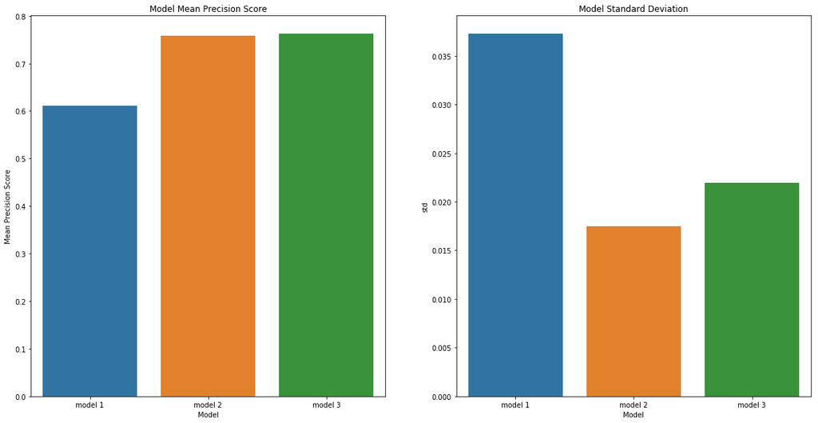

```python
m_score = [np.mean(precision_score_list_m1), np.mean(precision_score_list_m2), np.mean(precision_score_list_m3)]
m_std = [np.std(precision_score_list_m1), np.std(precision_score_list_m2), np.std(precision_score_list_m3)]
m_name = ['model 1', 'model 2', 'model 3']
m_compare = pd.DataFrame(m_score, columns=['Mean Precision Score'])
m_compare.insert(loc = 1, column = 'Model', value = m_name)
m_compare.insert(loc = 2, column='std', value = m_std)

f, (ax1, ax2) = plt.subplots(nrows = 1, ncols = 2, figsize=(20,10))
sns.barplot(x='Model', y='Mean Precision Score', data=m_compare, ax=ax1)
sns.barplot(x='Model', y='std', data=m_compare, ax=ax2)
ax1.set_title('Model Mean Precision Score')
ax2.set_title('Model Standard Deviation')
plt.show()
```

In comparing the three model above, lets look to the graphical representations above. From the plot of the left, it is seen that model 1 had the worst mean precision score at ~ 61 %, while model 2 and model 3 were roughly on par with each other at ~ 76 %. Thus solely from the plot on the left the best of the above models is not obvious. To decipher which is better model 2 or model 3, lets look to the standard deviation in the precision score for the models on the right. From this is clear that model 2 is the better model due to the significantly lesser standard deviation in its precision score.

#### 3.3 Generalization Performance

The performance of the various networks below will be measured on their mean precision score using Stratified K-Fold cross validation as argued for in the beginning of the lab.

###### 3.3.1 (1) Deep Layer

For the first observation, I will constrain the wide and deep network to only have 1 deep layer with 10 neurons.

```python
def create_model_1_deep_layer(X_train, X_test, X_train_numeric, categorical_feature_columns_ints, cross_columns):

    embed_branches = []
    X_ints_train = []
    X_ints_test = []
    all_inputs = []
    all_branch_outputs = []

    for cols in cross_columns:
        enc = LabelEncoder()
        X_crossed_train = X_train[cols].apply(lambda x: '_'.join(x), axis = 1)
        X_crossed_test = X_test[cols].apply(lambda x: '_'.join(x), axis = 1)

        enc.fit(np.hstack((X_crossed_train.values, X_crossed_test.values)))
        X_crossed_train = enc.transform(X_crossed_train)
        X_crossed_test = enc.transform(X_crossed_test)
        X_ints_train.append(X_crossed_train)
        X_ints_test.append(X_crossed_test)

        N = max(X_ints_train[-1] + 1)

        inputs = Input(shape=(1,),dtype='int32', name = '_'.join(cols))
        all_inputs.append(inputs)
        x = Embedding(input_dim = N, output_dim = int(np.sqrt(N)), input_length = 1, name = '_'.join(cols) + '_embed')(inputs)
        x = Flatten()(x)
        all_branch_outputs.append(x)

    wide_branch = concatenate(all_branch_outputs, name='wide_concat')

    all_branch_outputs = []

    for col in categorical_feature_columns_ints:
        X_ints_train.append( X_train[col].values )
        X_ints_test.append( X_test[col].values )

        N = max(X_ints_train[-1]+1)

        inputs = Input(shape = (1,), dtype = 'int32', name = col)
        all_inputs.append(inputs)
        x = Embedding(input_dim = N, output_dim = int(np.sqrt(N)), input_length = 1, name = col + '_embed')(inputs)
        x = Flatten()(x)
        all_branch_outputs.append(x)

    all_inputs.append(Input(shape=(X_train_numeric.shape[1],), sparse = False, name = 'numeric_data'))

    x = Dense(units = 20, activation = 'relu',name = 'numeric_1')(all_inputs[-1])
    all_branch_outputs.append(x)

    # merge the branches together
    deep_branch = concatenate(all_branch_outputs,name='concat_embeds')
    deep_branch = Dense(units = 10, activation = 'relu', name = 'deep3')(deep_branch)

    final_branch = concatenate([wide_branch, deep_branch], name = 'concat_deep_wide')
    final_branch = Dense(units = 1, activation = 'sigmoid',name = 'combined')(final_branch)

    model = Model(inputs = all_inputs, outputs = final_branch)

    return model, X_ints_train, X_ints_test
```

```python
K = 10

cross_columns = [['content_rating', 'genres'], ['language', 'country']]

precision_score_1_deep_layer_list = []

skf = StratifiedKFold(n_splits = K, shuffle = True).split(X,y)

for i, (train, test) in enumerate(skf):
    print('Fold:', i)

    X_train = df.iloc[train]
    X_test = df.iloc[test]
    y_train = df['class'].iloc[train].values.astype(np.int)
    y_test = df['class'].iloc[test].values.astype(np.int)

    X_train_numeric = X_train[numeric_feature_columns].values
    X_test_numeric = X_test[numeric_feature_columns].values

    model, X_ints_train, X_ints_test = create_model_1_deep_layer(X_train, X_test, X_train_numeric, categorical_feature_columns_ints, cross_columns)

    model.compile(optimizer = 'adagrad', loss = 'binary_crossentropy', metrics = ['accuracy'])

    model.fit(X_ints_train + [X_train_numeric], y_train, epochs = 10, batch_size = 10, verbose = 0, validation_data = (X_ints_test + [X_test_numeric], y_test))

    yhat = np.round(model.predict(X_ints_test + [X_test_numeric]))

    score = precision_score(y_test, yhat)
    precision_score_1_deep_layer_list.append(score)

    print(confusion_matrix(y_test, yhat))
    print('Precision Score:', score)

print('1 Deep Layer Model Max Precision Score:', max(precision_score_1_deep_layer_list))
print('1 Deep Layer Model Mean Precision Score:', np.mean(precision_score_1_deep_layer_list))
print('1 Deep Layer Model STD Precision Score:', np.std(precision_score_1_deep_layer_list))
```

```
Fold: 0
[[ 93  43]
 [ 51 122]]
Precision Score: 0.7393939393939394
Fold: 1
[[ 81  54]
 [ 49 124]]
Precision Score: 0.6966292134831461
Fold: 2
[[102  33]
 [ 54 119]]
Precision Score: 0.7828947368421053
Fold: 3
[[ 94  41]
 [ 54 119]]
Precision Score: 0.74375
Fold: 4
[[ 80  55]
 [ 39 134]]
Precision Score: 0.708994708994709
Fold: 5
[[ 92  43]
 [ 42 131]]
Precision Score: 0.7528735632183908
Fold: 6
[[ 85  50]
 [ 39 133]]
Precision Score: 0.726775956284153
Fold: 7
[[ 92  43]
 [ 32 140]]
Precision Score: 0.7650273224043715
Fold: 8
[[ 88  47]
 [ 45 127]]
Precision Score: 0.7298850574712644
Fold: 9
[[ 87  48]
 [ 54 118]]
Precision Score: 0.7108433734939759
1 Deep Layer Model Max Precision Score: 0.7828947368421053
1 Deep Layer Model Mean Precision Score: 0.7357067871586056
1 Deep Layer Model STD Precision Score: 0.02536102609724249
```

From the 1 deep layer model statistics above, it is seen that using 1 deep layer, the model achieved a mean precision score of 73.5 % with standard deviation of 0.025.

Below, lets visualize the performance over each fold for the 1 deep layer model.

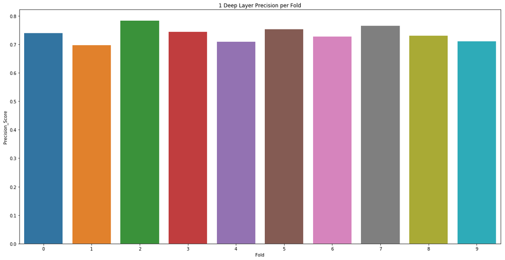

```python
fold = [0,1,2,3,4,5,6,7,8,9]
deep1 = pd.DataFrame(precision_score_1_deep_layer_list, columns = ['Precision_Score'])
deep1.insert(loc = 1, column='Fold', value = fold)

plt.figure(figsize = (20,10))
sns.barplot(x = 'Fold', y = 'Precision_Score', data = deep1)
plt.title('1 Deep Layer Precision per Fold')
plt.show()
```

###### 3.3.2 (3) Deep Layers

For the next obervation I will use 3 deep layers with 100, 25, and 10 neurons, respectively.

```python
def create_model_3_deep_layer(X_train, X_test, X_train_numeric, categorical_feature_columns_ints, cross_columns):

    embed_branches = []
    X_ints_train = []
    X_ints_test = []
    all_inputs = []
    all_branch_outputs = []

    for cols in cross_columns:
        enc = LabelEncoder()
        X_crossed_train = X_train[cols].apply(lambda x: '_'.join(x), axis = 1)
        X_crossed_test = X_test[cols].apply(lambda x: '_'.join(x), axis = 1)

        enc.fit(np.hstack((X_crossed_train.values, X_crossed_test.values)))
        X_crossed_train = enc.transform(X_crossed_train)
        X_crossed_test = enc.transform(X_crossed_test)
        X_ints_train.append(X_crossed_train)
        X_ints_test.append(X_crossed_test)

        N = max(X_ints_train[-1] + 1)

        inputs = Input(shape=(1,),dtype='int32', name = '_'.join(cols))
        all_inputs.append(inputs)
        x = Embedding(input_dim = N, output_dim = int(np.sqrt(N)), input_length = 1, name = '_'.join(cols) + '_embed')(inputs)
        x = Flatten()(x)
        all_branch_outputs.append(x)

    wide_branch = concatenate(all_branch_outputs, name='wide_concat')

    all_branch_outputs = []

    for col in categorical_feature_columns_ints:
        X_ints_train.append( X_train[col].values )
        X_ints_test.append( X_test[col].values )

        N = max(X_ints_train[-1]+1)

        inputs = Input(shape = (1,), dtype = 'int32', name = col)
        all_inputs.append(inputs)
        x = Embedding(input_dim = N, output_dim = int(np.sqrt(N)), input_length = 1, name = col + '_embed')(inputs)
        x = Flatten()(x)
        all_branch_outputs.append(x)

    all_inputs.append(Input(shape=(X_train_numeric.shape[1],), sparse = False, name = 'numeric_data'))

    x = Dense(units = 20, activation = 'relu',name = 'numeric_1')(all_inputs[-1])
    all_branch_outputs.append(x)

    # merge the branches together
    deep_branch = concatenate(all_branch_outputs,name='concat_embeds')
    deep_branch = Dense(units = 100,activation = 'relu', name = 'deep1')(deep_branch)
    deep_branch = Dense(units = 25,activation = 'relu', name = 'deep2')(deep_branch)
    deep_branch = Dense(units = 10,activation = 'relu', name = 'deep3')(deep_branch)

    final_branch = concatenate([wide_branch, deep_branch], name = 'concat_deep_wide')
    final_branch = Dense(units = 1,activation = 'sigmoid',name = 'combined')(final_branch)

    model = Model(inputs = all_inputs, outputs = final_branch)

    return model, X_ints_train, X_ints_test
```

```python
K = 10

cross_columns = [['content_rating', 'genres'], ['language', 'country']]

precision_score_3_deep_layer_list = []

skf = StratifiedKFold(n_splits = K, shuffle = True).split(X,y)

for i, (train, test) in enumerate(skf):
    print('Fold:', i)

    X_train = df.iloc[train]
    X_test = df.iloc[test]
    y_train = df['class'].iloc[train].values.astype(np.int)
    y_test = df['class'].iloc[test].values.astype(np.int)

    X_train_numeric = X_train[numeric_feature_columns].values
    X_test_numeric = X_test[numeric_feature_columns].values

    model, X_ints_train, X_ints_test = create_model_3_deep_layer(X_train, X_test, X_train_numeric, categorical_feature_columns_ints, cross_columns)

    model.compile(optimizer = 'adagrad', loss = 'binary_crossentropy', metrics = ['accuracy'])

    model.fit(X_ints_train + [X_train_numeric], y_train, epochs = 10, batch_size = 10, verbose = 0, validation_data = (X_ints_test + [X_test_numeric], y_test))

    yhat = np.round(model.predict(X_ints_test + [X_test_numeric]))

    score = precision_score(y_test, yhat)
    precision_score_3_deep_layer_list.append(score)

    print(confusion_matrix(y_test, yhat))
    print('Precision Score:', score)

print('3 Deep Layer Model Max Precision Score:', max(precision_score_3_deep_layer_list))
print('3 Deep Layer Model Mean Precision Score:', np.mean(precision_score_3_deep_layer_list))
print('3 Deep Layer Model STD Precision Score:', np.std(precision_score_3_deep_layer_list))
```

```
Fold: 0
[[101  35]
 [ 43 130]]
Precision Score: 0.7878787878787878
Fold: 1
[[ 93  42]
 [ 38 135]]
Precision Score: 0.7627118644067796
Fold: 2
[[ 76  59]
 [ 28 145]]
Precision Score: 0.7107843137254902
Fold: 3
[[ 85  50]
 [ 39 134]]
Precision Score: 0.7282608695652174
Fold: 4
[[ 82  53]
 [ 49 124]]
Precision Score: 0.7005649717514124
Fold: 5
[[ 93  42]
 [ 40 133]]
Precision Score: 0.76
Fold: 6
[[106  29]
 [ 37 135]]
Precision Score: 0.823170731707317
Fold: 7
[[109  26]
 [ 49 123]]
Precision Score: 0.825503355704698
Fold: 8
[[ 90  45]
 [ 26 146]]
Precision Score: 0.7643979057591623
Fold: 9
[[ 88  47]
 [ 30 142]]
Precision Score: 0.7513227513227513
3 Deep Layer Model Max Precision Score: 0.825503355704698
3 Deep Layer Model Mean Precision Score: 0.7614595551821617
3 Deep Layer Model STD Precision Score: 0.04012633043361714
```

With 3 Deep Layers the models mean precision marginally improved to 76.1 %, while the standard deviation marginally got worse to 0.04. From this observation it is seems that with greater number of deep layers we see the precision of the model get better, with a little increased variance. In the next observation, I will make the network even deeper and see if examine the effect on the average precision of the model

Below, lets again visualize the performance over each fold for the 3 deep layer model.

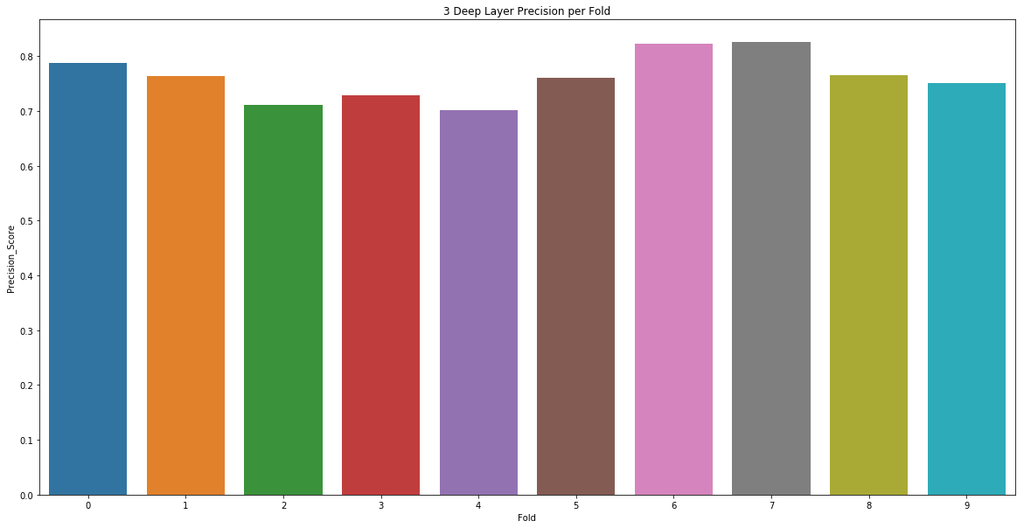

```python
fold = [0,1,2,3,4,5,6,7,8,9]
deep3 = pd.DataFrame(precision_score_3_deep_layer_list, columns = ['Precision_Score'])
deep3.insert(loc = 1, column='Fold', value = fold)

plt.figure(figsize = (20,10))
sns.barplot(x = 'Fold', y = 'Precision_Score', data = deep3)
plt.title('3 Deep Layer Precision per Fold')
plt.show()
```

###### 3.3.3 (5) Deep Layers

For the following observation, I will use 5 deep layers with 100, 75, 50, 25, and 10 neurons, respectively.

```python
def create_model_5_deep_layer(X_train, X_test, X_train_numeric, categorical_feature_columns_ints, cross_columns):

    embed_branches = []
    X_ints_train = []
    X_ints_test = []
    all_inputs = []
    all_branch_outputs = []

    for cols in cross_columns:
        enc = LabelEncoder()
        X_crossed_train = X_train[cols].apply(lambda x: '_'.join(x), axis = 1)
        X_crossed_test = X_test[cols].apply(lambda x: '_'.join(x), axis = 1)

        enc.fit(np.hstack((X_crossed_train.values, X_crossed_test.values)))
        X_crossed_train = enc.transform(X_crossed_train)
        X_crossed_test = enc.transform(X_crossed_test)
        X_ints_train.append(X_crossed_train)
        X_ints_test.append(X_crossed_test)

        N = max(X_ints_train[-1] + 1)

        inputs = Input(shape=(1,),dtype='int32', name = '_'.join(cols))
        all_inputs.append(inputs)
        x = Embedding(input_dim = N, output_dim = int(np.sqrt(N)), input_length = 1, name = '_'.join(cols) + '_embed')(inputs)
        x = Flatten()(x)
        all_branch_outputs.append(x)

    wide_branch = concatenate(all_branch_outputs, name='wide_concat')

    all_branch_outputs = []

    for col in categorical_feature_columns_ints:
        X_ints_train.append( X_train[col].values )
        X_ints_test.append( X_test[col].values )

        N = max(X_ints_train[-1]+1)

        inputs = Input(shape = (1,), dtype = 'int32', name = col)
        all_inputs.append(inputs)
        x = Embedding(input_dim = N, output_dim = int(np.sqrt(N)), input_length = 1, name = col + '_embed')(inputs)
        x = Flatten()(x)
        all_branch_outputs.append(x)

    all_inputs.append(Input(shape=(X_train_numeric.shape[1],), sparse = False, name = 'numeric_data'))

    x = Dense(units = 20, activation = 'relu',name = 'numeric_1')(all_inputs[-1])
    all_branch_outputs.append(x)

    # merge the branches together
    deep_branch = concatenate(all_branch_outputs,name='concat_embeds')
    deep_branch = Dense(units = 100,activation = 'relu', name = 'deep1')(deep_branch)
    deep_branch = Dense(units = 75,activation = 'relu', name = 'deep2')(deep_branch)
    deep_branch = Dense(units = 50,activation = 'relu', name = 'deep3')(deep_branch)
    deep_branch = Dense(units = 25,activation = 'relu', name = 'deep4')(deep_branch)
    deep_branch = Dense(units = 10,activation = 'relu', name = 'deep5')(deep_branch)

    final_branch = concatenate([wide_branch, deep_branch], name = 'concat_deep_wide')
    final_branch = Dense(units = 1,activation = 'sigmoid',name = 'combined')(final_branch)

    model = Model(inputs = all_inputs, outputs = final_branch)

    return model, X_ints_train, X_ints_test
```

```python
K = 10

cross_columns = [['content_rating', 'genres'], ['language', 'country']]

precision_score_5_deep_layer_list = []

skf = StratifiedKFold(n_splits = K, shuffle = True).split(X,y)

for i, (train, test) in enumerate(skf):
    print('Fold:', i)

    X_train = df.iloc[train]
    X_test = df.iloc[test]
    y_train = df['class'].iloc[train].values.astype(np.int)
    y_test = df['class'].iloc[test].values.astype(np.int)

    X_train_numeric = X_train[numeric_feature_columns].values
    X_test_numeric = X_test[numeric_feature_columns].values

    model, X_ints_train, X_ints_test = create_model_5_deep_layer(X_train, X_test, X_train_numeric, categorical_feature_columns_ints, cross_columns)

    model.compile(optimizer = 'adagrad', loss = 'binary_crossentropy', metrics = ['accuracy'])

    model.fit(X_ints_train + [X_train_numeric], y_train, epochs = 10, batch_size = 10, verbose = 0, validation_data = (X_ints_test + [X_test_numeric], y_test))

    yhat = np.round(model.predict(X_ints_test + [X_test_numeric]))

    score = precision_score(y_test, yhat)
    precision_score_5_deep_layer_list.append(score)

    print(confusion_matrix(y_test, yhat))
    print('Precision Score:', score)

print('5 Deep Layer Model Max Precision Score:', max(precision_score_5_deep_layer_list))
print('5 Deep Layer Model Mean Precision Score:', np.mean(precision_score_5_deep_layer_list))
print('5 Deep Layer Model STD Precision Score:', np.std(precision_score_5_deep_layer_list))
```

```
Fold: 0
[[100  36]
 [ 46 127]]
Precision Score: 0.7791411042944786
Fold: 1
[[ 89  46]
 [ 28 145]]
Precision Score: 0.7591623036649214
Fold: 2
[[ 83  52]
 [ 36 137]]
Precision Score: 0.7248677248677249
Fold: 3
[[ 95  40]
 [ 45 128]]
Precision Score: 0.7619047619047619
Fold: 4
[[ 85  50]
 [ 36 137]]
Precision Score: 0.732620320855615
Fold: 5
[[102  33]
 [ 41 132]]
Precision Score: 0.8
Fold: 6
[[ 87  48]
 [ 46 126]]
Precision Score: 0.7241379310344828
Fold: 7
[[ 99  36]
 [ 48 124]]
Precision Score: 0.775
Fold: 8
[[ 94  41]
 [ 30 142]]
Precision Score: 0.7759562841530054
Fold: 9
[[ 90  45]
 [ 52 120]]
Precision Score: 0.7272727272727273
5 Deep Layer Model Max Precision Score: 0.8
5 Deep Layer Model Mean Precision Score: 0.7560063158047717
5 Deep Layer Model STD Precision Score: 0.025752486390263733
```

As represented by the 5 deep layer model statistics, the mean precision score slightly decreased to 75.6 %, while the standard deviation improved to 0.02.

Below, lets again visualize the performance over each fold for the 5 deep layer model.

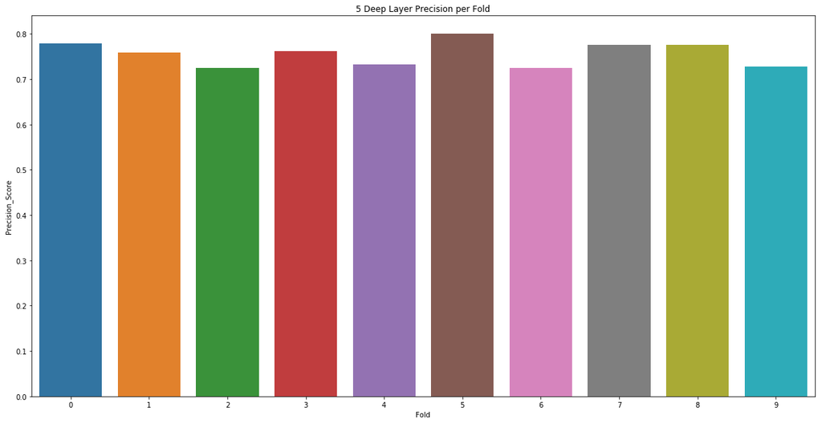

```python
fold = [0,1,2,3,4,5,6,7,8,9]
deep5 = pd.DataFrame(precision_score_5_deep_layer_list, columns = ['Precision_Score'])
deep5.insert(loc = 1, column='Fold', value = fold)

plt.figure(figsize = (20,10))
sns.barplot(x = 'Fold', y = 'Precision_Score', data = deep5)
plt.title('5 Deep Layer Precision per Fold')
plt.show()
```

###### 3.3.4 Discussion of the effect that the number of deep network layers has on the model precision

In exploring the effect that the number of deep layers in the network has on the precision of the model, it can be seen that the moderately deep network with 3 layers was able to achieve the best mean precision score performance. While there was an increase in performance when increasing the number of deep layers from 1 to 3, the performance fell of slightly when increasing the number of layers to 5 from 3. However, in choosing the "best" model from above, lets graphically compare the mean precision scores and standard deviations from the 3 deep layer models below.

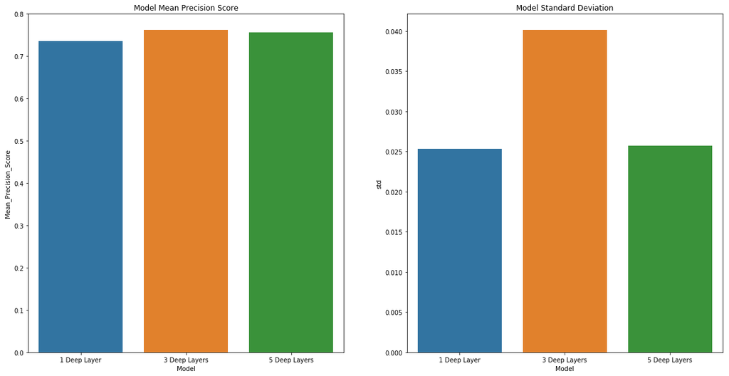

```python
m_deep_score = [np.mean(precision_score_1_deep_layer_list), np.mean(precision_score_3_deep_layer_list), np.mean(precision_score_5_deep_layer_list)]
m_deep_std = [np.std(precision_score_1_deep_layer_list), np.std(precision_score_3_deep_layer_list), np.std(precision_score_5_deep_layer_list)]
m_deep_name = ['1 Deep Layer', '3 Deep Layers', '5 Deep Layers']
m_deep_compare = pd.DataFrame(m_deep_score, columns = ['Mean_Precision_Score'])
m_deep_compare.insert(loc = 1, column = 'Model', value = m_deep_name)
m_deep_compare.insert(loc = 2, column = 'std', value = m_deep_std)

f, (ax1, ax2) = plt.subplots(nrows = 1, ncols = 2, figsize=(20,10))
sns.barplot(x='Model', y='Mean_Precision_Score', data=m_deep_compare, ax=ax1)
sns.barplot(x='Model', y='std', data=m_deep_compare, ax=ax2)
ax1.set_title('Model Mean Precision Score')
ax2.set_title('Model Standard Deviation')
plt.show()
```

In comparing the performance of the models with differing number of deep layers in the network in regards to the precision of the model, lets again look at both the mean precision score of the model, and the standard deviations in the precision score. From the plot on the left, it is seen that the 1 deep layer network had the worst performance with a mean precision score of ~ 73 %, while the 3 and 5 deep layer networks had roughly equal performance with mean precision scores of ~ 76 %, with the 3 deep layer network slightly outperforming the 5 deep layer network. Again, solely from looking at the mean precision scores of the three different networks, it is not apparent which network is the best performer. To distinguish which is the better network, lets look at the standard deviations in the mean precision scores, illustrated on the right. In examining the standard deviation, it is apparent that the 5 deep layer model is the better performer as it was able to achieve roughly the same mean precision as the 3 deep layer network, with a significantly lower standard deviation.

Thus the 5 deep layer network is the best performing model.

#### 3.4 My Best Wide and Deep Network

Above, we explored the effect that altering the number of deep layers in the network has on the precision of the model. Up to this point, we have not really explored too many other model parameters which could boost performance. Below, lets perform a some hyperparameter tuning and see if we can increase the model precision. Because the 5 deep layer network achieved the overall performance, lets stick with a 5 layer model and focus on parameters such as the optimization method, the loss function, the number of epochs, and the batch_size.

Because the purpose of this exploration is to tune hyperparameters I will only run the model for 2 fold cross validation to save time as the point of this exercise is not to better understand generalization performance but to achieve optimal performance through hyperparameter tuning.

To select the optimal parameters that will be used in my best performing model, I will select the parameters which return the highest precision score.

```python
def create_model_optimized(X_train, X_test, X_train_numeric, categorical_feature_columns_ints, cross_columns):

    embed_branches = []
    X_ints_train = []
    X_ints_test = []
    all_inputs = []
    all_branch_outputs = []

    for cols in cross_columns:
        enc = LabelEncoder()
        X_crossed_train = X_train[cols].apply(lambda x: '_'.join(x), axis = 1)
        X_crossed_test = X_test[cols].apply(lambda x: '_'.join(x), axis = 1)

        enc.fit(np.hstack((X_crossed_train.values, X_crossed_test.values)))
        X_crossed_train = enc.transform(X_crossed_train)
        X_crossed_test = enc.transform(X_crossed_test)
        X_ints_train.append(X_crossed_train)
        X_ints_test.append(X_crossed_test)

        N = max(X_ints_train[-1] + 1)

        inputs = Input(shape=(1,),dtype='int32', name = '_'.join(cols))
        all_inputs.append(inputs)
        x = Embedding(input_dim = N, output_dim = int(np.sqrt(N)), input_length = 1, name = '_'.join(cols) + '_embed')(inputs)
        x = Flatten()(x)
        all_branch_outputs.append(x)

    wide_branch = concatenate(all_branch_outputs, name='wide_concat')

    all_branch_outputs = []

    for col in categorical_feature_columns_ints:
        X_ints_train.append( X_train[col].values )
        X_ints_test.append( X_test[col].values )

        N = max(X_ints_train[-1]+1)

        inputs = Input(shape = (1,), dtype = 'int32', name = col)
        all_inputs.append(inputs)
        x = Embedding(input_dim = N, output_dim = int(np.sqrt(N)), input_length = 1, name = col + '_embed')(inputs)
        x = Flatten()(x)
        all_branch_outputs.append(x)

    all_inputs.append(Input(shape=(X_train_numeric.shape[1],), sparse = False, name = 'numeric_data'))

    x = Dense(units = 20, activation = 'relu',name = 'numeric_1')(all_inputs[-1])
    all_branch_outputs.append(x)

    # merge the branches together
    deep_branch = concatenate(all_branch_outputs,name='concat_embeds')
    deep_branch = Dense(units = 100,activation = 'relu', name = 'deep1')(deep_branch)
    deep_branch = Dense(units = 75,activation = 'relu', name = 'deep2')(deep_branch)
    deep_branch = Dense(units = 50,activation = 'relu', name = 'deep3')(deep_branch)
    deep_branch = Dense(units = 25,activation = 'relu', name = 'deep4')(deep_branch)
    deep_branch = Dense(units = 10,activation = 'relu', name = 'deep5')(deep_branch)

    final_branch = concatenate([wide_branch, deep_branch], name = 'concat_deep_wide')
    final_branch = Dense(units = 1,activation = 'sigmoid',name = 'combined')(final_branch)

    model = Model(inputs = all_inputs, outputs = final_branch)

    return model, X_ints_train, X_ints_test
```

```python
num_folds = 2
cross_columns = [['content_rating', 'genres'], ['language', 'country']]
precision_score_optimized_array = {}
optimization_table = []

skf = StratifiedKFold(n_splits = num_folds, shuffle = True).split(X,y)

optimizer_list = ['adagrad', 'adam']
loss_list = ['mean_squared_error', 'binary_crossentropy']
epochs_list = [10, 20]
batch_list = [10, 50, 100]

idx = 0
for i, (train, test) in enumerate(skf):
    for o in optimizer_list:
        for l in loss_list:
            for e in epochs_list:
                for b in batch_list:
                    print('Optimizer:', o, 'loss:', l,'epochs:', e, 'batch_size:', b)
                    X_train = df.iloc[train]
                    X_test = df.iloc[test]
                    y_train = df['class'].iloc[train].values.astype(np.int)
                    y_test = df['class'].iloc[test].values.astype(np.int)
                    X_train_numeric = X_train[numeric_feature_columns].values
                    X_test_numeric = X_test[numeric_feature_columns].values
                    model, X_ints_train, X_ints_test = create_model_optimized(X_train, X_test, X_train_numeric, categorical_feature_columns_ints, cross_columns)
                    model.compile(optimizer = o, loss = l, metrics = ['accuracy'])
                    model.fit(X_ints_train + [X_train_numeric], y_train, epochs = e, batch_size = b, verbose = 0) #validation_data = (X_ints_test + [X_test_numeric], y_test))
                    yhat = np.round(model.predict(X_ints_test + [X_test_numeric]))
                    score = precision_score(y_test, yhat)
                    precision_score_optimized_array[score] = (o, l, e, b)
                    optimization_table.insert(idx, (o, l, e, b, score))
                    idx += 1
                    print('Precision Score:', score)
```

```
Optimizer: adagrad loss: mean_squared_error epochs: 10 batch_size: 10
Precision Score: 0.7212249208025343
Optimizer: adagrad loss: mean_squared_error epochs: 10 batch_size: 50
Precision Score: 0.7664516129032258
Optimizer: adagrad loss: mean_squared_error epochs: 10 batch_size: 100
Precision Score: 0.7683686176836861
Optimizer: adagrad loss: mean_squared_error epochs: 20 batch_size: 10
Precision Score: 0.7320125130344108
Optimizer: adagrad loss: mean_squared_error epochs: 20 batch_size: 50
Precision Score: 0.7250268528464017
Optimizer: adagrad loss: mean_squared_error epochs: 20 batch_size: 100
Precision Score: 0.7371134020618557
Optimizer: adagrad loss: binary_crossentropy epochs: 10 batch_size: 10
Precision Score: 0.7176350662589195
Optimizer: adagrad loss: binary_crossentropy epochs: 10 batch_size: 50
Precision Score: 0.7471655328798186
Optimizer: adagrad loss: binary_crossentropy epochs: 10 batch_size: 100
Precision Score: 0.7361894024802705
Optimizer: adagrad loss: binary_crossentropy epochs: 20 batch_size: 10
Precision Score: 0.6867030965391621
Optimizer: adagrad loss: binary_crossentropy epochs: 20 batch_size: 50
Precision Score: 0.7155425219941349
Optimizer: adagrad loss: binary_crossentropy epochs: 20 batch_size: 100
Precision Score: 0.7571428571428571
Optimizer: adam loss: mean_squared_error epochs: 10 batch_size: 10
Precision Score: 0.6867145421903053
Optimizer: adam loss: mean_squared_error epochs: 10 batch_size: 50
Precision Score: 0.79750346740638
Optimizer: adam loss: mean_squared_error epochs: 10 batch_size: 100
Precision Score: 0.7412993039443155
Optimizer: adam loss: mean_squared_error epochs: 20 batch_size: 10
Precision Score: 0.7881040892193308
Optimizer: adam loss: mean_squared_error epochs: 20 batch_size: 50
Precision Score: 0.7816993464052288
Optimizer: adam loss: mean_squared_error epochs: 20 batch_size: 100
Precision Score: 0.7602820211515864
Optimizer: adam loss: binary_crossentropy epochs: 10 batch_size: 10
Precision Score: 0.7464167585446527
Optimizer: adam loss: binary_crossentropy epochs: 10 batch_size: 50
Precision Score: 0.7436194895591647
```

[output cut: 41 more lines]

```
Precision Score: 0.7246673490276356
Optimizer: adam loss: mean_squared_error epochs: 20 batch_size: 100
Precision Score: 0.7194029850746269
Optimizer: adam loss: binary_crossentropy epochs: 10 batch_size: 10
Precision Score: 0.7772215269086358
Optimizer: adam loss: binary_crossentropy epochs: 10 batch_size: 50
Precision Score: 0.6930970149253731
Optimizer: adam loss: binary_crossentropy epochs: 10 batch_size: 100
Precision Score: 0.7738246505717916
Optimizer: adam loss: binary_crossentropy epochs: 20 batch_size: 10
Precision Score: 0.7185761957730812
Optimizer: adam loss: binary_crossentropy epochs: 20 batch_size: 50
Precision Score: 0.7861111111111111
Optimizer: adam loss: binary_crossentropy epochs: 20 batch_size: 100
Precision Score: 0.7122736418511066
```

```python
# Lets view the optimal parameters from the hyperparameter tuning
print('Optimized Model Max Precision Score:', max(precision_score_optimized_array))
print('Max Precision Parameter Values (Optimizer, Loss, epochs, batch_size):', precision_score_optimized_array[max(precision_score_optimized_array.keys())])
```

```
Optimized Model Max Precision Score: 0.8002915451895044
Max Precision Parameter Values (Optimizer, Loss, epochs, batch_size): ('adam', 'binary_crossentropy', 20, 100)
```

From the cell above, via the hyperparameter tuning I was able to achieve a precision score of 80 % with the following parameters:

- Optimizer: adam
- Loss: binary_crossentropy
- Epochs: 20
- Batch_size: 100

###### 3.4.1 Optimized Model

Via the hyperparameter tuning above, in optimizing the precision of the model I was able to achieve a precision score of 80 % percent with the following model parameters:

- optimizer: adam
- loss: binary_crossentropy
- epochs: 20
- batch_size = 100
- Number Deep Layers: 5
- Neurons in Each layer: 100, 75, 50, 25, 10

Lets build my optimal model below, which will be used in the comparision to the scikit learn MLP.

```python
def create_model_optimized(X_train, X_test, X_train_numeric, categorical_feature_columns_ints, cross_columns):

    embed_branches = []
    X_ints_train = []
    X_ints_test = []
    all_inputs = []
    all_branch_outputs = []

    for cols in cross_columns:
        enc = LabelEncoder()
        X_crossed_train = X_train[cols].apply(lambda x: '_'.join(x), axis = 1)
        X_crossed_test = X_test[cols].apply(lambda x: '_'.join(x), axis = 1)

        enc.fit(np.hstack((X_crossed_train.values, X_crossed_test.values)))
        X_crossed_train = enc.transform(X_crossed_train)
        X_crossed_test = enc.transform(X_crossed_test)
        X_ints_train.append(X_crossed_train)
        X_ints_test.append(X_crossed_test)

        N = max(X_ints_train[-1] + 1)

        inputs = Input(shape=(1,),dtype='int32', name = '_'.join(cols))
        all_inputs.append(inputs)
        x = Embedding(input_dim = N, output_dim = int(np.sqrt(N)), input_length = 1, name = '_'.join(cols) + '_embed')(inputs)
        x = Flatten()(x)
        all_branch_outputs.append(x)

    wide_branch = concatenate(all_branch_outputs, name='wide_concat')

    all_branch_outputs = []

    for col in categorical_feature_columns_ints:
        X_ints_train.append( X_train[col].values )
        X_ints_test.append( X_test[col].values )

        N = max(X_ints_train[-1]+1)

        inputs = Input(shape = (1,), dtype = 'int32', name = col)
        all_inputs.append(inputs)
        x = Embedding(input_dim = N, output_dim = int(np.sqrt(N)), input_length = 1, name = col + '_embed')(inputs)
        x = Flatten()(x)
        all_branch_outputs.append(x)

    all_inputs.append(Input(shape=(X_train_numeric.shape[1],), sparse = False, name = 'numeric_data'))

    x = Dense(units = 20, activation = 'relu',name = 'numeric_1')(all_inputs[-1])
    all_branch_outputs.append(x)

    # merge the branches together
    deep_branch = concatenate(all_branch_outputs,name='concat_embeds')
    deep_branch = Dense(units = 100,activation = 'relu', name = 'deep1')(deep_branch)
    deep_branch = Dense(units = 75,activation = 'relu', name = 'deep2')(deep_branch)
    deep_branch = Dense(units = 50,activation = 'relu', name = 'deep3')(deep_branch)
    deep_branch = Dense(units = 25,activation = 'relu', name = 'deep4')(deep_branch)
    deep_branch = Dense(units = 10,activation = 'relu', name = 'deep5')(deep_branch)

    final_branch = concatenate([wide_branch, deep_branch], name = 'concat_deep_wide')
    final_branch = Dense(units = 1,activation = 'sigmoid',name = 'combined')(final_branch)

    model = Model(inputs = all_inputs, outputs = final_branch)

    return model, X_ints_train, X_ints_test
```

```python
K = 10

cross_columns = [['content_rating', 'genres'], ['language', 'country']]

precision_score_optimized_model = []

skf = StratifiedKFold(n_splits = K, shuffle = True).split(X,y)

for i, (train, test) in enumerate(skf):
    print('Fold:', i)

    X_train = df.iloc[train]
    X_test = df.iloc[test]
    y_train = df['class'].iloc[train].values.astype(np.int)
    y_test = df['class'].iloc[test].values.astype(np.int)

    X_train_numeric = X_train[numeric_feature_columns].values
    X_test_numeric = X_test[numeric_feature_columns].values

    model, X_ints_train, X_ints_test = create_model_optimized(X_train, X_test, X_train_numeric, categorical_feature_columns_ints, cross_columns)

    model.compile(optimizer = 'adam', loss = 'binary_crossentropy', metrics = ['accuracy'])
    model.fit(X_ints_train + [X_train_numeric], y_train, epochs = 20, batch_size = 100, verbose = 0, validation_data = (X_ints_test + [X_test_numeric], y_test))

    yhat = np.round(model.predict(X_ints_test + [X_test_numeric]))

    score = precision_score(y_test, yhat)
    precision_score_optimized_model.append(score)

    print(confusion_matrix(y_test, yhat))
    print('Precision Score:', score)

print('Optimized Model Max Precision Score:', max(precision_score_optimized_model))
print('Optimized Model Mean Precision Score:', np.mean(precision_score_optimized_model))
print('Optimized Model STD Precision Score:', np.std(precision_score_optimized_model))
```

```
Fold: 0
[[109  27]
 [ 53 120]]
Precision Score: 0.8163265306122449
Fold: 1
[[ 97  38]
 [ 45 128]]
Precision Score: 0.7710843373493976
Fold: 2
[[ 81  54]
 [ 26 147]]
Precision Score: 0.7313432835820896
Fold: 3
[[ 98  37]
 [ 37 136]]
Precision Score: 0.7861271676300579
Fold: 4
[[ 81  54]
 [ 22 151]]
Precision Score: 0.7365853658536585
Fold: 5
[[ 95  40]
 [ 43 130]]
Precision Score: 0.7647058823529411
Fold: 6
[[ 93  42]
 [ 49 123]]
Precision Score: 0.7454545454545455
Fold: 7
[[102  33]
 [ 41 131]]
Precision Score: 0.7987804878048781
Fold: 8
[[108  27]
 [ 39 133]]
Precision Score: 0.83125
Fold: 9
[[ 87  48]
 [ 32 140]]
Precision Score: 0.7446808510638298
Optimized Model Max Precision Score: 0.83125
Optimized Model Mean Precision Score: 0.7726338451703644
Optimized Model STD Precision Score: 0.03286390445306099
```

From the statistics of my best wide and deep network model above, I was able to achieve a mean precision score of 77.2 % with a standard deviation of 0.032.

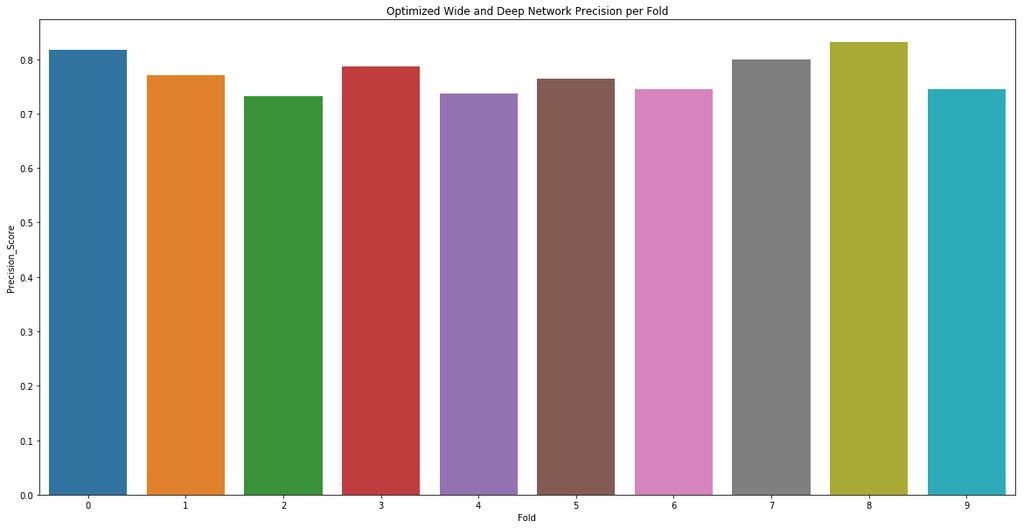

```python
fold = [0,1,2,3,4,5,6,7,8,9]
best = pd.DataFrame(precision_score_optimized_model, columns = ['Precision_Score'])
best.insert(loc = 1, column='Fold', value = fold)

plt.figure(figsize = (20,10))
sns.barplot(x = 'Fold', y = 'Precision_Score', data = best)
plt.title('Optimized Wide and Deep Network Precision per Fold')
plt.show()
```

#### 3.5 Comparision to Standard MLP

Below is the Scikit Learn implementation of a multi-layer perceptron which will be compared to the performance of my best model.

###### 3.5.1 Scikit-Learn's Standard MLP

```python
from sklearn.neural_network import MLPClassifier
sklearnmlp = MLPClassifier()
```

```python
K = 10

sklearn_precision_list = []

skf = StratifiedKFold(n_splits = K, shuffle = True).split(X,y)

for i, (train, test) in enumerate(skf):
    print('Fold:', i)

    X_train = df.iloc[train]
    X_test = df.iloc[test]
    y_train = df['class'].iloc[train].values.astype(np.int)
    y_test = df['class'].iloc[test].values.astype(np.int)

    X_train_numeric = X_train[numeric_feature_columns].values
    X_test_numeric = X_test[numeric_feature_columns].values

    sklearnmlp.fit(X_train_numeric, y_train)
    yhat = sklearnmlp.predict(X_test_numeric)
    print(confusion_matrix(y_test, yhat))
    score = precision_score(y_test, yhat)
    sklearn_precision_list.append(score)
    print('Precision Score:', score)

print('Max sklearn MLP Precision Score:', max(sklearn_precision_list))
print('Mean sklearn MLP Precision Score:', np.mean(sklearn_precision_list))
print('STD sklearn MLP Precision Score:', np.std(sklearn_precision_list))
```

```
Fold: 0
[[ 97  39]
 [ 35 138]]
Precision Score: 0.7796610169491526
Fold: 1
[[ 89  46]
 [ 42 131]]
Precision Score: 0.7401129943502824
Fold: 2
[[ 90  45]
 [ 40 133]]
Precision Score: 0.7471910112359551
Fold: 3
[[ 87  48]
 [ 35 138]]
Precision Score: 0.7419354838709677
Fold: 4
[[ 96  39]
 [ 40 133]]
Precision Score: 0.7732558139534884
Fold: 5
[[ 84  51]
 [ 38 135]]
Precision Score: 0.7258064516129032
Fold: 6
[[ 95  40]
 [ 40 132]]
Precision Score: 0.7674418604651163
Fold: 7
[[ 90  45]
 [ 43 129]]
Precision Score: 0.7413793103448276
Fold: 8
```

```
[[101  34]
 [ 50 122]]
Precision Score: 0.782051282051282
Fold: 9
[[111  24]
 [ 39 133]]
Precision Score: 0.8471337579617835
Max sklearn MLP Precision Score: 0.8471337579617835
Mean sklearn MLP Precision Score: 0.7645968982795759
STD sklearn MLP Precision Score: 0.032995012231134525
```

From the statistics of scikit-learn's standard MLP above, it was able to achieve a mean precision score of 76.4 % with a standard deviation of 0.032

A quick comparison of the performance of the scikit-learn's MLP to my best wide and deep network shows that my best wide and deep network was a able to achieve a percent more accuracy in regards to precision with the same standard deviation. However, there is much more valuable information which can be analyzed to really compare these two models and derive which model is the better performer.

###### 3.5.2 Reciever Operating Characteristic and Area Under the Curve

Below, we are going to look at the Reciever Operating Characteristic (ROC) curve and the Area Under the Curve (AUC) as one method to compare scikit-learn's MLP to my best wide and deep network. ROC curves are useful tools which to aid in selecting classification models based on their performance with respect to the False Positive Rate and True Positive Rate. ROC curves are constructed by shifting the decision threshold of the classifier, and counting the number of True Positives and False Negatives both above and below the threshold. The diagonal of an ROC curve represents random guessing, while a perfect classifier would have a True Positive Rate of 1 and a False Positive Rate if 0, represented in the ROC curve below. Once an ROC curve has been calculated, more information can be derived from the AUC to characterize the classification performance of a model, with a greater AUC commonly indicating a better model[3].

Below, lets compute and graphically examine the ROC and AUC of scikit-learn's MLP and my best wide and deep network.

[3] Raschka, Sebastian & Mirkalili, Vahid. Python Machine Learning.

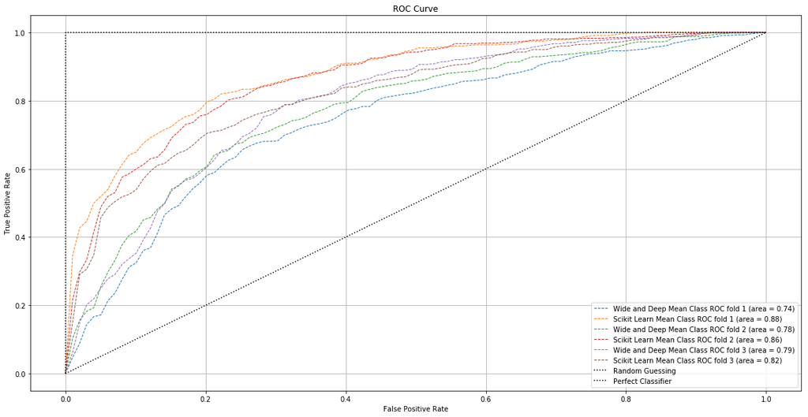

```python
%matplotlib inline
plt.figure(figsize = (20,10))

mean_tpr = 0.0
mean_fpr = np.linspace(0,1,100)
all_tpr = []

skf = StratifiedKFold(n_splits = 3, random_state = 1).split(X, y)

for i, (train, test) in enumerate(skf):
    X_train = df.iloc[train]
    X_test = df.iloc[test]
    y_train = df['class'].iloc[train].values.astype(np.int)
    y_test = df['class'].iloc[test].values.astype(np.int)

    X_train_numeric = X_train[numeric_feature_columns].values
    X_test_numeric = X_test[numeric_feature_columns].values

    model, X_ints_train, X_ints_test = create_model_optimized(X_train, X_test, X_train_numeric, categorical_feature_columns_ints, cross_columns)
    model.compile(optimizer = 'adam', loss = 'binary_crossentropy', metrics = ['accuracy'])
    model.fit(X_ints_train + [X_train_numeric], y_train, epochs = 20, batch_size = 100, verbose = 0)

    predict_WD = model.predict(X_ints_test + [X_test_numeric])
    predict_SK = sklearnmlp.predict_proba(X_test_numeric)

    perclass_mean_tpr = 0.0
    roc_auc = 0
    classes = np.unique(y_train)

    fpr, tpr, thresholds = roc_curve(y_test, predict_WD, pos_label=1)
    perclass_mean_tpr += interp(mean_fpr, fpr, tpr)
    perclass_mean_tpr[0] = 0.0
    roc_auc += auc(fpr, tpr)

    plt.plot(mean_fpr, perclass_mean_tpr, '--', lw = 1, label = 'Wide and Deep Mean Class ROC fold %d (area = %0.2f)' % (i + 1, roc_auc))

    perclass_mean_tpr = 0.0
    roc_auc = 0
    classes = np.unique(y_train)

    fpr, tpr, thresholds = roc_curve(y_test, predict_SK[:,1], pos_label=1) # This grabs the positive predicted values
    perclass_mean_tpr += interp(mean_fpr, fpr, tpr)
    perclass_mean_tpr[0] = 0.0
    roc_auc += auc(fpr, tpr)

    plt.plot(mean_fpr, perclass_mean_tpr, '--', lw = 1, label = 'Scikit Learn Mean Class ROC fold %d (area = %0.2f)' % (i + 1, roc_auc))

    # The following code is taken and slightly modified from Raschka, Sebastian & Mirkalili, Vahid. Python Machine Learning.
plt.plot([0,1], [0,1], linestyle = ':', color = 'black', label = 'Random Guessing')

plt.plot([0,0,1], [0,1,1], linestyle = ':', color = 'black', label = 'Perfect Classifier' )

plt.grid()
plt.xlabel('False Positive Rate', fontsize = 10)
plt.ylabel('True Positive Rate', fontsize = 10)
plt.title('ROC Curve')
plt.legend(loc = 'best', fontsize = 10)
plt.show()
```

Lets use the ROC curve and AUC to determine which classifier is the better choice for the prediction task at hand. In the ROC curve above I have indicated what the performance of a perfect classifier would look like and also what random guessing would look like.

In examining the ROC curve it is seen that scikit-learn's standard MLP outperformed my best wide and deep network in each fold. That is scikit-learn's standard MLP had ROC curves closer to that of a perfect classifier. Also, the average AUC over the three folds for scikit-learn standard MLP was 0.85, while the average AUC for my best wide and deep network over the same three folds was 0.77. Thus, one observation I could make is that based on the average AUC, scikit-learn's standard MLP is the better classifier.

However, there is much more information to be derived from the ROC curve. The ROC curve is also a useful tool in determining the operating point, or decision threshold of a classifier[4]. For instance, if we wanted an operating point that minimized the number of false positives, the scikit-learn MLP would again be the obvious choice as the ROC curve has the steepest slope in the beginning ranging from 0.0 to 0.2 over the False Positive Rate, which shows the algorithm is classifying a very small number of false positives for the number of true positives over this range.

This example is really apparent in looking at the ROC for fold 3. In examining this particular fold it is seen that the MLP ROC curve actually dips below my best wide and deep network ROC curve at about 0.4 on the False Positive Rate. Even though this is the case, I would still say over this fold the MLP ROC curve still looks like the better curve because it contains the most area underneath it over the range of 0.0 to 0.2 on the False Positive Rate. Meaning that the MLP, over fold 3, is classifying fewer false positives per true positives, than my best wide and deep network.

Thus, scikit-learn's standard MLP is the better classifier for the prediction task at hand.

[4] The use of the area under the roc curve in the evaluation of machine learning algorithms, A. P, Bradley, Pattern Recognition. https://ac.els-cdn.com/S0031320396001422/1-s2.0-S0031320396001422-main.pdf?_tid=30002a09-e7fc-4c07-963e-a508b8f848f0&acdnat=1523827123_7f358b8b4f41c54b8b627a9f02352d75

###### 3.5.3 Statistical Comparision

Above, we established that scikit-learn's MLP is the better classifier for the prediction task of this dataset. Next, lets explore if we can statistically prove this as well. When I say statistically, I mean can we say the scikit-learn MLP is the better classifier with confidence greater than 95 %.

To statistically compare the performance of my best wide and deep model versus scikit-learns standard MLP, I am going to perform a T-Test. More specifically, I will approximate the bounds using the folds of the cross fold validation to get a mean and variance of the precision score. I believe this is the most appropriate means of generating confidence intervals because both models were trained using the same data, and therefore across the same instances. For the T-Test I will use a t value of 2.26 and k = 10 (note that this is lowercase k and not capital K, which indicated the number of folds in the cross validation).

If the resulting confidence interval does not include 0, then statistically, with 95 % confidence, we can say that the scikit-learn MLP is the better classifier.

```python
K = 10

skf = StratifiedKFold(n_splits = 10, random_state = 1).split(X, y)

precision_score_WD = []
precision_score_SK = []

for i, (train, test) in enumerate(skf):
    X_train = df.iloc[train]
    X_test = df.iloc[test]
    y_train = df['class'].iloc[train].values.astype(np.int)
    y_test = df['class'].iloc[test].values.astype(np.int)

    X_train_numeric = X_train[numeric_feature_columns].values
    X_test_numeric = X_test[numeric_feature_columns].values

    model, X_ints_train, X_ints_test = create_model_optimized(X_train, X_test, X_train_numeric, categorical_feature_columns_ints, cross_columns)
    model.compile(optimizer = 'adam', loss = 'binary_crossentropy', metrics = ['accuracy'])
    model.fit(X_ints_train + [X_train_numeric], y_train, epochs = 20, batch_size = 100, verbose = 0)

    sklearnmlp.fit(X_train_numeric, y_train)

    yhat_WD = np.round(model.predict(X_ints_test + [X_test_numeric]))
    yhat_SK = sklearnmlp.predict(X_test_numeric)

    precision_WD = precision_score(y_test, yhat_WD)
    precision_SK = precision_score(y_test, yhat_SK)

    precision_score_WD.append(precision_WD)
    precision_score_SK.append(precision_SK)
```

```python
precision_score_WD = np.asarray(precision_score_WD)
precision_score_SK = np.asarray(precision_score_SK)
```

```python
k = 10
t = 2.26 / np.sqrt(k)

# Compare wide and deep network to scikit-learn's MLP

e = (1 - precision_score_SK) - (1 - precision_score_WD)
stdtot = np.std(e)
dbar = np.mean(e)
print('Confidence Interval:', dbar - t * stdtot, '->', dbar + t * stdtot)
```

```
Confidence Interval: -0.013779766823929965 -> 0.03738893726632602
```

In the statistical comparison of my best wide and deep network with scikit-learn's standard MLP, I cannot say with 95 % confidence which model is the better classifier due to the fact that the confidence interval includes 0.

However, from the ROC curve above I believe scikit-learn's MLP is the better classifier for the prediction task of this dataset.

# 4. T-SNE Embedded Layer Weight Clustering and Visualization

In this section we will be exploring clustering techniques applied to the embedding weights of the wide and deep network used in my optimized model with the purpose to derive meaningful information regarding categorical features and their corresponding weights.

For the T-SNE clustering exercise in this section, I chose to keep the parameters of the T-SNE method tame. This is because the embedding weights for various embedded layers in the network is not complex or large scale data by any means. Thus, I did not find it necessary to set the perplexity of the T-SNE method to a large value nor set the number of iterations to a large number. In experimenting with the parameters, I actually found I could derive more meaningful clusters when these parameters were kept low.

#### 4.1 Get the Layer Weights

```python
from sklearn.manifold import TSNE
```

```python
# Print out the names of the model layers
for layer in model.layers:
    print(layer, ':', layer.name)
```

```
<keras.engine.topology.InputLayer object at 0x1ad7709c50> : color_int
<keras.engine.topology.InputLayer object at 0x1ad76f24e0> : genres_int
<keras.engine.topology.InputLayer object at 0x1ad771b668> : language_int
<keras.engine.topology.InputLayer object at 0x1ad76d4dd8> : country_int
<keras.engine.topology.InputLayer object at 0x1ad76be860> : content_rating_int
<keras.layers.embeddings.Embedding object at 0x1ad7709e80> : color_int_embed
<keras.layers.embeddings.Embedding object at 0x1ad7712240> : genres_int_embed
<keras.layers.embeddings.Embedding object at 0x1ad76d4160> : language_int_embed
<keras.layers.embeddings.Embedding object at 0x1ad76beb70> : country_int_embed
<keras.layers.embeddings.Embedding object at 0x1ad768e5f8> : content_rating_int_embed
<keras.engine.topology.InputLayer object at 0x1ad76ff320> : numeric_data
<keras.layers.core.Flatten object at 0x1ad7709cf8> : flatten_1739
<keras.layers.core.Flatten object at 0x1ad7712c50> : flatten_1740
<keras.layers.core.Flatten object at 0x1ad76d4518> : flatten_1741
<keras.layers.core.Flatten object at 0x1ad76bef28> : flatten_1742
<keras.layers.core.Flatten object at 0x1ad768eb70> : flatten_1743
<keras.layers.core.Dense object at 0x1ad768e898> : numeric_1
<keras.layers.merge.Concatenate object at 0x1ad7697940> : concat_embeds
<keras.layers.core.Dense object at 0x1ad7697be0> : deep1
<keras.engine.topology.InputLayer object at 0x1ad76cbd30> : content_rating_genres
<keras.engine.topology.InputLayer object at 0x1ad76cb9b0> : language_country
<keras.layers.core.Dense object at 0x1ad7677358> : deep2
<keras.layers.embeddings.Embedding object at 0x1ad76cb208> : content_rating_genres_embed
<keras.layers.embeddings.Embedding object at 0x1ad76e7ef0> : language_country_embed
<keras.layers.core.Dense object at 0x1ad7743f60> : deep3
<keras.layers.core.Flatten object at 0x1ad76cb2e8> : flatten_1737
<keras.layers.core.Flatten object at 0x1ad76e7898> : flatten_1738
<keras.layers.core.Dense object at 0x1ad0e2c6d8> : deep4
<keras.layers.merge.Concatenate object at 0x1ad76e7d68> : wide_concat
<keras.layers.core.Dense object at 0x1ad0e5fc50> : deep5
<keras.layers.merge.Concatenate object at 0x1ad2c56e48> : concat_deep_wide
<keras.layers.core.Dense object at 0x1ad2c702b0> : combined
```

#### 4.2 Embedding Weights for Genres

One interesting feature to explore is the movie genre. Let's see if there is any correlation or anti-correlation between the weights of any of the various movie genres. For instance, because Action and Adventure are closely related genres, I hope to observe the corresponding weights for the two genres cluster well together, while I would like to see the weights for Horror and Comedy to not cluster well.

```python
print(model.layers[6].name)
genres_int_embed_weight = model.layers[6].get_weights()
print(genres_int_embed_weight)
```

```
genres_int_embed
[array([[-0.0326324 , -0.1686731 ],
       [-0.10637511, -0.00146679],
       [-0.11770006,  0.06419343],
       [ 0.08155245,  0.08705894],
       [-0.02194081, -0.03428854],
       [-0.00902892, -0.06623175],
       [ 0.14523144,  0.1558044 ]], dtype=float32)]
```

```python
df.genres.unique()
```

```
array(['Action', 'Adventure', 'Drama', 'Comedy', 'Crime', 'Biography',
       'Horror'], dtype=object)
```

```python
# Do not touch these values as they prodcue interesting clusters
tsne_genres = TSNE(n_iter=250, n_components=2, learning_rate=200, perplexity=3).fit_transform(genres_int_embed_weight[0])
```

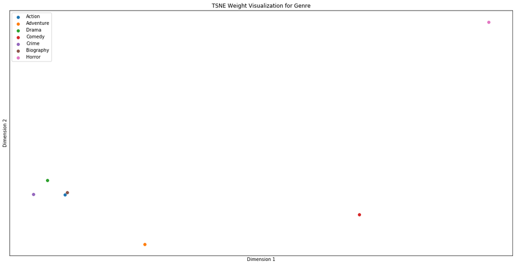

```python
X_tsne_genre_df = pd.DataFrame(tsne_genres, columns = ['X', 'Y'])
X_tsne_genre_df.insert(loc = 2, column = 'genre', value = df.genres.unique())

fig, ax = plt.subplots(figsize = (20,10))

for i in X_tsne_genre_df.index:
    plt.scatter(x = X_tsne_genre_df.X[i], y = X_tsne_genre_df.Y[i], label = X_tsne_genre_df.genre[i])


plt.title('TSNE Weight Visualization for Genre')
plt.legend(loc = 'best')
plt.xlabel('Dimension 1')
plt.ylabel('Dimension 2')
plt.xticks([])
plt.yticks([])
plt.show()
```

#### 4.3 Embedding Weights for Content Rating

Another interesting feature to examine is the content rating of the movie. Again here, I would like to see the embedding weights for similar ratings such as PG and PG-13 cluster well together, while the weights for ratings R and G not to cluster well together.

```python
print(model.layers[9].name)
content_rating_int_embed_weight = model.layers[9].get_weights()
print(genres_int_embed_weight)
```

```
content_rating_int_embed
[array([[-0.0326324 , -0.1686731 ],
       [-0.10637511, -0.00146679],
       [-0.11770006,  0.06419343],
       [ 0.08155245,  0.08705894],
       [-0.02194081, -0.03428854],
       [-0.00902892, -0.06623175],
       [ 0.14523144,  0.1558044 ]], dtype=float32)]
```

```python
tsne_rating = TSNE(n_iter=250, n_components=2 ,learning_rate=200, perplexity=3).fit_transform(content_rating_int_embed_weight[0])
```

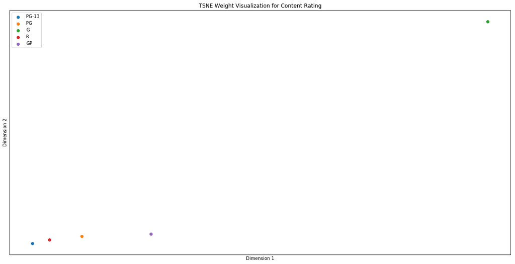

```python
X_tsne_rating_df = pd.DataFrame(tsne_rating, columns = ['X', 'Y'])
X_tsne_rating_df.insert(loc = 2, column = 'rating', value = df.content_rating.unique())

fig, ax = plt.subplots(figsize = (20,10))

for i in X_tsne_rating_df.index:
    plt.scatter(x = X_tsne_rating_df.X[i], y = X_tsne_rating_df.Y[i], label = X_tsne_rating_df.rating[i])

plt.title('TSNE Weight Visualization for Content Rating')
plt.legend(loc = 'best')
plt.xlabel('Dimension 1')
plt.ylabel('Dimension 2')
plt.xticks([])
plt.yticks([])
plt.show()
```

In viewing the embedding weights for the content rating of a movie, again we see some interesting relationships. From the T-SNE weight visualization above, we see that the embedding weights for ratings PG-13, R, and PG, cluster very closely together. While the G rating weights is a meaningful distance away from all other ratings. Again this is interesting to observe, as movie ratings such as PG-13, PG, and R are more closely related than movies rated G, which also seems to be reflected in the embedding weights of the network.